# Thesis

```r
#library(igraph)
#library(ggraph)
#library(ggplot2)

links <- data.frame(
  from = c("2", "2", "2", "2", "3", "3", "3", "3", "5"),
  to   = c("4", "6", "9", "10", "10", "1", "5", "7", "8")
)
net <- graph_from_data_frame(d = links, directed = FALSE)

V(net)$degree <- degree(net)

pdf("plots/rvine_tree_ggraph.pdf", width = 6, height = 6)

set.seed(10+4595440)

ggraph(net, layout = "fr") +
  geom_edge_link(color = "black", width = 0.8, alpha = 0.8) +

  geom_node_point(
    aes(fill = degree),
    shape = 22,
    size = 13,
    color = "#333333",
    stroke = 0.8
  ) +

  geom_node_text(
    aes(label = name),
    color = "white",
    fontface = "bold",
    size = 6,
    family = "sans"
  ) +

  scale_fill_gradient(
    low = "#5C88B9",
    high = "#1F3B5C",
    name = "Degree"
  ) +

  theme_graph(base_family = "sans") +
  theme(
    legend.position = "none",
    plot.margin = margin(10, 10, 10, 10)
  )

dev.off()
```

### parameters

```r
pdf("plots/vine_contour.pdf")
contour(vine_fit, cex=1.1)
dev.off()
```

```r
round(vine_fit$tau,4)
```

```
##          [,1]    [,2]    [,3]    [,4]    [,5]    [,6]    [,7]    [,8]    [,9]
##  [1,]  0.0000  0.0000  0.0000  0.0000  0.0000  0.0000  0.0000  0.0000  0.0000
##  [2,]  0.0000  0.0000  0.0000  0.0000  0.0000  0.0000  0.0000  0.0000  0.0000
##  [3,] -0.0314  0.0352  0.0000  0.0000  0.0000  0.0000  0.0000  0.0000  0.0000
##  [4,] -0.0328  0.0302 -0.0245  0.0000  0.0000  0.0000  0.0000  0.0000  0.0000
##  [5,]  0.0000  0.0000  0.0346 -0.0346  0.0000  0.0000  0.0000  0.0000  0.0000
##  [6,] -0.0255 -0.0408  0.0000 -0.0077 -0.0034  0.0000  0.0000  0.0000  0.0000
##  [7,]  0.0000 -0.0131  0.0419  0.0000 -0.0031  0.0000  0.0000  0.0000  0.0000
##  [8,] -0.0019  0.0056  0.0000  0.0355  0.0212 -0.0039  0.0154  0.0000  0.0000
##  [9,] -0.0060 -0.0352 -0.0634  0.0000 -0.0185  0.0449 -0.0285  0.0563  0.0000
## [10,] -0.0511 -0.0759  0.0350 -0.0875 -0.1058 -0.0684  0.0865 -0.0832 -0.0754
##       [,10]
##  [1,]     0
##  [2,]     0
##  [3,]     0
##  [4,]     0
##  [5,]     0
##  [6,]     0
##  [7,]     0
##  [8,]     0
##  [9,]     0
## [10,]     0
```

**vine_fit$tau** contains the estimated **Kendall’s tau values** for the pair-copulas in the vine structure**.**

**Kendall’s tau:** a rank based measure of dependence strength between two variables.

Unlike Pearson correlation, it captures:

- nonlinear dependence
- monotonic relationships
- dependence implied by copulas

  and kendall’s tau is more robust to outliers and heavy tails.

| Tau value | Meaning |
| --- | --- |
| 0 | independence |
| 0.1–0.3 | weak dependence |
| 0.3–0.6 | moderate dependence |
| 0.6+ | strong dependence |
| negative | inverse dependence |

```r
extract_vine_table <- function(vine_fit) {
  d <- ncol(vine_fit$Matrix)
  mat <- vine_fit$Matrix
  fam_mat <- vine_fit$family
  tau_mat <- round(vine_fit$tau, 4)

  result <- list()

  # Loop over trees (Tree 1 corresponds to bottom row d of the matrices)
  for (t in 1:(d - 1)) {
    row_idx <- d - t + 1

    for (col_idx in 1:(d - t)) {
      # Node 1 is the element at row_idx, col_idx
      v1 <- mat[row_idx, col_idx]
      # Node 2 is the diagonal element for that column
      v2 <- mat[col_idx, col_idx]

      # Extract conditioning set (elements in matrix above row_idx in that column)
      if (row_idx < d) {
        cond_set <- mat[(row_idx + 1):d, col_idx]
        cond_str <- paste(sort(cond_set), collapse = ",")
        edge_label <- paste0(v1, ",", v2, " | ", cond_str)
      } else {
        edge_label <- paste0(v1, ",", v2)
      }

      fam_code <- fam_mat[row_idx, col_idx]
      fam_name <- BiCopName(fam_code, short = FALSE)
      tau_val <- tau_mat[row_idx, col_idx]

      result[[length(result) + 1]] <- data.frame(
        Tree = t,
        Edge = edge_label,
        Family_Code = fam_code,
        Family_Name = fam_name,
        Kendall_Tau = tau_val,
        stringsAsFactors = FALSE
      )
    }
  }

  do.call(rbind, result)
}

# Generate the summary table
vine_summary_df <- extract_vine_table(vine_fit)

# View the full table or just Tree 1
head(vine_summary_df, 9)
```

```
##   Tree Edge Family_Code               Family_Name Kendall_Tau
## 1    1  5,8           1                  Gaussian     -0.0511
## 2    1  3,5          36   Rotated Joe 270 degrees     -0.0759
## 3    1  3,1           6                       Joe      0.0350
## 4    1  2,6          36   Rotated Joe 270 degrees     -0.0875
## 5    1  2,4          36   Rotated Joe 270 degrees     -0.1058
## 6    1  3,7           2                         t     -0.0684
## 7    1  2,9           2                         t      0.0865
## 8    1 10,2          24 Rotated Gumbel 90 degrees     -0.0832
## 9    1 10,3          24 Rotated Gumbel 90 degrees     -0.0754
```

# Simulation

## step1. Generate uniform sample from fitted Vine copula

```r
burn_in = 1e4
N = 1e4 + burn_in #10000 for burn-in
set.seed(4595440)
u_sim = RVineSim(N, vine_fit)
```

## step2. Inverse PIT

Emprical Quantile

```r
z_sim <- sapply(1:ncol(u_sim), function(k) {
  quantile(Z[, k], probs = u_sim[, k], type = 8)
})
```

```r
dim(z_sim)
```

```
## [1] 20000    10
```

## step3. Generate f_t and sigma_t

[figure not shown]

```r
best_model = fits[[49]]
rownames(coef(best_model))
```

```
## [1] "omega"    "alpha1"   "beta1"    "skew"     "shape"    "ghlambda"
```

```r
omega = coef(best_model)["omega", ]
alpha1 = coef(best_model)["alpha1", ]
#alpha2 = coef(best_model)["alpha2", ]
beta1 = coef(best_model)["beta1", ]
```

Let, sigma_0 = sigma_1 = sqrt(omega/(1-alphas-beta))

```r
sigma_0 = sqrt(omega/(1-alpha1-beta1)) #alpha2-
f_0 = sigma_0 * z_sim[1,]
```

```r
sigma_sim <- matrix(NA, nrow = nrow(z_sim), ncol = ncol(z_sim))
f_sim     <- matrix(NA, nrow = nrow(z_sim), ncol = ncol(z_sim))

sigma_sim[1, ] <- sigma_0
#sigma_sim[2, ] <- sigma_1

f_sim[1, ] <- f_0
#f_sim[2, ] <- f_1

for(i in 2:nrow(z_sim)){

  sigma_square <-
    omega +
    alpha1 * f_sim[i-1, ]^2 +
    #alpha2 * f_sim[i-2, ]^2 +
    beta1  * sigma_sim[i-1, ]^2

  sigma_sim[i, ] <- sqrt(sigma_square)

  f_sim[i, ] <- sigma_sim[i, ] * z_sim[i, ]
}
```

```r
dim(f_sim)
```

```
## [1] 20000    10
```

```r
A = best_model@mfit$A
```

AR(1)

$$\mu_t = c+\phi \cdot\mu_{t-1} +
\epsilon_t$$

```r
round(best_model@mfit$arcoef,3)
```

```
##         [,1]   [,2]   [,3]  [,4]   [,5]   [,6]   [,7]   [,8]   [,9]  [,10]
## mu     0.001  0.001  0.002 0.003  0.001  0.004  0.001  0.000  0.000  0.001
## ar1   -0.028 -0.019 -0.068 0.010 -0.038 -0.020 -0.029 -0.359 -0.309 -0.026
## sigma  0.033  0.050  0.046 0.079  0.042  0.063  0.042  0.001  0.001  0.054
```

```r
eps_sim <- f_sim %*% t(A)

mu <- best_model@mfit$arcoef["mu",]
phi <- best_model@mfit$arcoef["ar1",]

x_sim_ar <- matrix(NA,
                   nrow=nrow(eps_sim),
                   ncol=ncol(eps_sim))

# initial value
x_sim_ar[1,] <- (1-phi)*mu + eps_sim[1,]

for(t in 2:nrow(eps_sim)){

  x_sim_ar[t,] <- (1-phi)*mu +
                  phi * x_sim_ar[t-1,] +
                  eps_sim[t,]
}
```

```r
dim(x_sim_ar)
```

```
## [1] 20000    10
```

## Validation

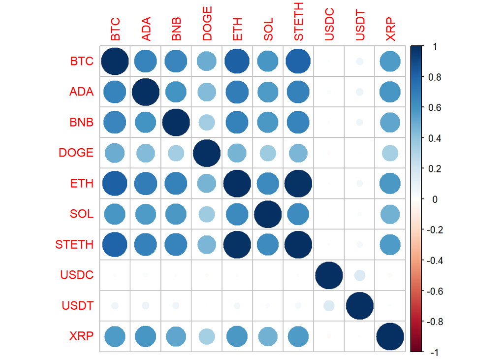

```r
#raw data
corrplot(cor_matrix)
```

```r
round(cor_matrix, 4)
```

```
##          BTC    ADA    BNB    DOGE     ETH     SOL   STETH    USDC    USDT
## BTC   1.0000 0.6670 0.6593  0.4976  0.8166  0.5862  0.8015  0.0134  0.0675
## ADA   0.6670 1.0000 0.5921  0.4379  0.6911  0.5694  0.6701  0.0246  0.0736
## BNB   0.6593 0.5921 1.0000  0.3420  0.6780  0.5768  0.6678  0.0190  0.0619
## DOGE  0.4976 0.4379 0.3420  1.0000  0.4626  0.3506  0.4527 -0.0201 -0.0067
## ETH   0.8166 0.6911 0.6780  0.4626  1.0000  0.6392  0.9812 -0.0101  0.0544
## SOL   0.5862 0.5694 0.5768  0.3506  0.6392  1.0000  0.6232 -0.0046  0.0271
## STETH 0.8015 0.6701 0.6678  0.4527  0.9812  0.6232  1.0000 -0.0108  0.0457
## USDC  0.0134 0.0246 0.0190 -0.0201 -0.0101 -0.0046 -0.0108  1.0000  0.1511
## USDT  0.0675 0.0736 0.0619 -0.0067  0.0544  0.0271  0.0457  0.1511  1.0000
## XRP   0.5664 0.5878 0.5235  0.3391  0.5797  0.4792  0.5667 -0.0257  0.0122
##           XRP
## BTC    0.5664
## ADA    0.5878
## BNB    0.5235
## DOGE   0.3391
## ETH    0.5797
## SOL    0.4792
## STETH  0.5667
## USDC  -0.0257
## USDT   0.0122
## XRP    1.0000
```

```r
#GO-GARCH + Vine-Copula Simulation
cor_Xsim <- cor(x_sim_ar[10001:2e4,], use = "pairwise.complete.obs")
```

```r
round(cor_Xsim, 4)
```

```
##         [,1]   [,2]   [,3]    [,4]    [,5]   [,6]    [,7]    [,8]   [,9]
##  [1,] 1.0000 0.8114 0.7052  0.5668  0.8218 0.7127  0.7192  0.0461 0.0949
##  [2,] 0.8114 1.0000 0.7031  0.5727  0.8085 0.7547  0.6723  0.0583 0.1460
##  [3,] 0.7052 0.7031 1.0000  0.4566  0.6994 0.6716  0.6630  0.0249 0.0694
##  [4,] 0.5668 0.5727 0.4566  1.0000  0.5308 0.4879  0.4809 -0.0130 0.0253
##  [5,] 0.8218 0.8085 0.6994  0.5308  1.0000 0.7601  0.8642 -0.0090 0.0614
##  [6,] 0.7127 0.7547 0.6716  0.4879  0.7601 1.0000  0.6602  0.0096 0.0899
##  [7,] 0.7192 0.6723 0.6630  0.4809  0.8642 0.6602  1.0000 -0.0026 0.0517
##  [8,] 0.0461 0.0583 0.0249 -0.0130 -0.0090 0.0096 -0.0026  1.0000 0.1002
##  [9,] 0.0949 0.1460 0.0694  0.0253  0.0614 0.0899  0.0517  0.1002 1.0000
## [10,] 0.6689 0.7292 0.6363  0.4646  0.6727 0.6356  0.5681 -0.0301 0.0352
##         [,10]
##  [1,]  0.6689
##  [2,]  0.7292
##  [3,]  0.6363
##  [4,]  0.4646
##  [5,]  0.6727
##  [6,]  0.6356
##  [7,]  0.5681
##  [8,] -0.0301
##  [9,]  0.0352
## [10,]  1.0000
```

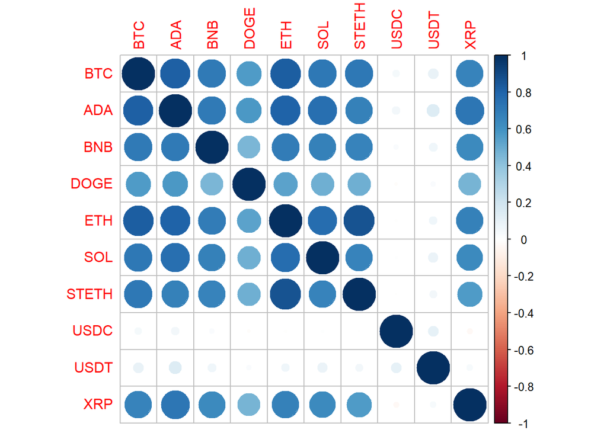

```r
rownames(cor_Xsim) <- asset_list
colnames(cor_Xsim) <- asset_list
corrplot(cor_Xsim)
```

```r
png(
  filename = "plots/correlation_matrix_sim.png",
  width = 1800,
  height = 1600,
  res = 200
)


corrplot(
  cor_Xsim,
  method = "color",
  type = "upper",
  addCoef.col = "black",
  tl.col = "black",
  tl.srt = 45,
  diag = FALSE,

  tl.cex = 1.5,        # ticker label
  number.cex = 1.5,    # correlation value
  cl.cex = 1.5         # legend (color bar)
)
```

**gogarchsim simulation**

```r
sim_model <- gogarchsim(best_model,
                        startMethod="unconditional",
                        n.sim=2e4, n.start=0, m.sim=1,
                        presigma = matrix(sigma_0, ncol = 1),
                        rseed = 4595440)
```

```r
x_sim_gogarch <- sim_model@msim$seriesSim[[1]][10001:20000, ]
```

```r
cor_Xsim_gogarch = cor(x_sim_gogarch, use = "pairwise.complete.obs")
round(cor_Xsim_gogarch, 4)
```

```
##          [,1]    [,2]   [,3]    [,4]    [,5]    [,6]    [,7]    [,8]    [,9]
##  [1,]  1.0000  0.8069 0.6747  0.5184  0.8357  0.7075  0.8310 -0.0569  0.0783
##  [2,]  0.8069  1.0000 0.6797  0.4654  0.7686  0.7319  0.7620 -0.0358  0.0866
##  [3,]  0.6747  0.6797 1.0000  0.2909  0.6253  0.7291  0.6187  0.0472  0.0637
##  [4,]  0.5184  0.4654 0.2909  1.0000  0.4127  0.3692  0.4079 -0.1191 -0.0068
##  [5,]  0.8357  0.7686 0.6253  0.4127  1.0000  0.7419  0.9985 -0.0174  0.0708
##  [6,]  0.7075  0.7319 0.7291  0.3692  0.7419  1.0000  0.7363 -0.0004  0.0624
##  [7,]  0.8310  0.7620 0.6187  0.4079  0.9985  0.7363  1.0000 -0.0168  0.0676
##  [8,] -0.0569 -0.0358 0.0472 -0.1191 -0.0174 -0.0004 -0.0168  1.0000  0.4032
##  [9,]  0.0783  0.0866 0.0637 -0.0068  0.0708  0.0624  0.0676  0.4032  1.0000
## [10,]  0.5484  0.7141 0.4473  0.3104  0.4616  0.4866  0.4584 -0.0989  0.0127
##         [,10]
##  [1,]  0.5484
##  [2,]  0.7141
##  [3,]  0.4473
##  [4,]  0.3104
##  [5,]  0.4616
##  [6,]  0.4866
##  [7,]  0.4584
##  [8,] -0.0989
##  [9,]  0.0127
## [10,]  1.0000
```

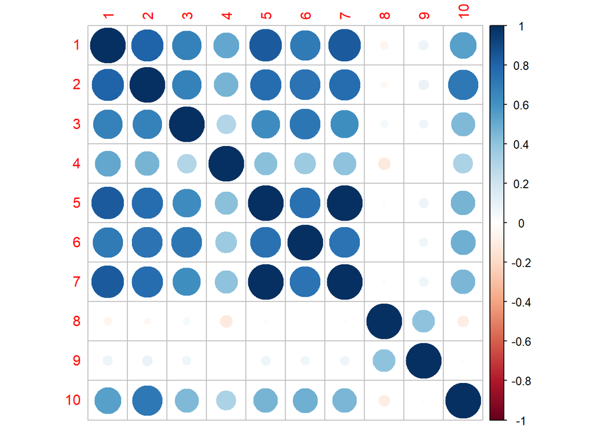

```r
corrplot(cor(x_sim_gogarch, use = "pairwise.complete.obs"))
```

```r
cor_Xsim_gogarch = cor(x_sim_gogarch, use = "pairwise.complete.obs")
rownames(cor_Xsim_gogarch)<-asset_list
colnames(cor_Xsim_gogarch)<-asset_list

png(
  filename = "plots/correlation_matrix_sim_gogarch.png",
  width = 1800,
  height = 1600,
  res = 200
)


corrplot(
  cor_Xsim_gogarch,
  method = "color",
  type = "upper",
  addCoef.col = "black",
  tl.col = "black",
  tl.srt = 45,
  diag = FALSE,

  tl.cex = 1.5,        # ticker label
  number.cex = 1.5,    # correlation value
  cl.cex = 1.5         # legend (color bar)
)
```

### Apply “Z” values from gogarchsim into manually generated function

```r
F_garchsim <- sim_model@msim$factor.residSim[[1]]
sigma_garchsim <- sim_model@msim$factor.sigmaSim[[1]]
Z_garchsim <- F_garchsim / sigma_garchsim
```

```r
sigma_0 = sigma_garchsim[1, ] #sqrt(omega/(1-alpha1-beta1)) #alpha2
#sigma_1 = sigma_0


sigma_sim_v <- matrix(NA, nrow = nrow(Z_garchsim), ncol = ncol(Z_garchsim))
f_sim_v     <- matrix(NA, nrow = nrow(Z_garchsim), ncol = ncol(Z_garchsim))

sigma_sim_v[1, ] <- sigma_0 #tail(best_model@mfit$factor.sigmas, 1)
#sigma_sim_v[2, ] <- sigma_1 #tail(best_model@mfit$factor.sigmas, 2)[1,]

f_0 = sigma_0 * Z_garchsim[1,]
#f_1 = sigma_1 * Z_garchsim[2,]


f_sim_v[1, ] <- f_0 #tail(best_model@mfit$Y, 1)
#f_sim_v[2, ] <- f_1 #tail(best_model@mfit$Y, 2)[1,]

for(i in 2:nrow(Z_garchsim)){

  sigma_square <-
    omega +
    alpha1 * f_sim_v[i-1, ]^2 +
#    alpha2 * f_sim_v[i-2, ]^2 +
    beta1  * sigma_sim_v[i-1, ]^2

  sigma_sim_v[i, ] <- sqrt(sigma_square)

  f_sim_v[i, ] <- sigma_sim_v[i, ] * Z_garchsim[i, ]
}
```

```r
#x_sim_v = f_sim_v %*% t(A)
eps_sim_v <- f_sim_v %*% t(A)

mu <- best_model@mfit$arcoef["mu",]
phi <- best_model@mfit$arcoef["ar1",]

x_sim_ar_v <- matrix(NA,
                   nrow=nrow(eps_sim_v),
                   ncol=ncol(eps_sim_v))

# initial value
x_sim_ar_v[1,] <- (1-phi)*mu + eps_sim_v[1,]

for(t in 2:nrow(eps_sim)){

  x_sim_ar_v[t,] <- (1-phi)*mu +
                phi * x_sim_ar_v[t-1,] +
                eps_sim_v[t,]
}
```

```r
summary(x_sim_ar_v[10001:2e4,] - x_sim_gogarch)
```

```
##        V1                   V2                   V3
##  Min.   :-3.331e-16   Min.   :-6.106e-16   Min.   :-4.441e-16
##  1st Qu.:-4.770e-18   1st Qu.:-6.939e-18   1st Qu.:-6.939e-18
##  Median : 0.000e+00   Median : 0.000e+00   Median : 0.000e+00
##  Mean   : 1.433e-20   Mean   : 1.725e-19   Mean   : 2.238e-19
##  3rd Qu.: 4.337e-18   3rd Qu.: 6.939e-18   3rd Qu.: 6.343e-18
##  Max.   : 4.441e-16   Max.   : 8.882e-16   Max.   : 5.551e-16
##        V4                   V5                   V6
##  Min.   :-1.332e-15   Min.   :-1.110e-15   Min.   :-8.882e-16
##  1st Qu.:-6.939e-18   1st Qu.:-6.939e-18   1st Qu.:-1.041e-17
##  Median : 0.000e+00   Median : 0.000e+00   Median : 0.000e+00
##  Mean   : 3.313e-19   Mean   : 3.980e-19   Mean   : 2.476e-19
##  3rd Qu.: 6.939e-18   3rd Qu.: 6.939e-18   3rd Qu.: 6.939e-18
##  Max.   : 1.776e-15   Max.   : 1.332e-15   Max.   : 1.110e-15
##        V7                   V8                   V9
##  Min.   :-1.110e-15   Min.   :-3.469e-18   Min.   :-1.041e-17
##  1st Qu.:-6.939e-18   1st Qu.:-1.355e-20   1st Qu.:-1.355e-20
##  Median : 0.000e+00   Median : 0.000e+00   Median : 0.000e+00
##  Mean   : 2.339e-19   Mean   : 2.383e-21   Mean   : 9.180e-23
##  3rd Qu.: 6.939e-18   3rd Qu.: 1.355e-20   3rd Qu.: 1.355e-20
##  Max.   : 1.332e-15   Max.   : 1.735e-18   Max.   : 1.388e-17
##       V10
##  Min.   :-1.776e-15
##  1st Qu.:-6.939e-18
##  Median : 0.000e+00
##  Mean   : 5.471e-20
##  3rd Qu.: 6.072e-18
##  Max.   : 1.776e-15
```

```r
all.equal(x_sim_ar_v[10001:20000,], x_sim_gogarch)
```

```
## [1] TRUE
```

# Tail Risk: VaR, ES

```r
dim(x_sim_ar)
```

```
## [1] 20000    10
```

```r
dim(x_sim_gogarch)
```

```
## [1] 10000    10
```

```r
dim(df_filtered)
```

```
## [1] 1437   10
```

```r
# 1. Define portfolio weights
w <- rep(1/10, 10)

# 2. Create list of returns datasets
data_list <- list(
  "Observed"   = exp(df_filtered) - 1,
  "GO-GARCH"   = exp(x_sim_gogarch) - 1,
    "gogarch+vc"     = exp(x_sim_ar[(burn_in + 1):nrow(x_sim_ar), ])-1
  ) #exp(sim_results$x_sim) -

# 3. Define function to compute VaR and ES
calc_risk_metrics <- function(ret_matrix, weights) {
  # Calculate portfolio return series
  port_ret <- as.vector(as.matrix(ret_matrix) %*% weights)

  # Compute quantiles at 5% and 1% levels
  q95 <- unname(quantile(port_ret, 0.05))
  q99 <- unname(quantile(port_ret, 0.01))

  # Compute VaR & ES (expressed as positive loss values)
  data.frame(
    VaR_95 = -q95,
    VaR_99 = -q99,
    ES_95  = -mean(port_ret[port_ret <= q95]),
    ES_99  = -mean(port_ret[port_ret <= q99])
  )
}

# 4. Apply metric function across datasets and row-bind into summary table
results_list <- lapply(data_list, calc_risk_metrics, weights = w)
results_df <- do.call(rbind, results_list)

# Display final table
print(results_df)
```

```
##                VaR_95     VaR_99      ES_95     ES_99
## Observed   0.04806749 0.08639318 0.07167957 0.1180730
## GO-GARCH   0.05990163 0.13091718 0.10720933 0.2052991
## gogarch+vc 0.06203268 0.11892034 0.09803053 0.1615916
```

# Extra works…!

## For repetitive works, Generate Functions…

```r
go_garch_conditions
```

```
##    p q mean_model     ica   dist       ll       AIC LB_raw_pass LB_squared_pass
## 1  1 1   constant fastica mvnorm 45182.88 -90305.76           8              10
## 2  2 1   constant fastica mvnorm       NA        NA          NA              NA
## 3  1 2   constant fastica mvnorm       NA        NA          NA              NA
## 4  1 1         AR fastica mvnorm 45353.17 -90646.33           8              10
## 5  2 1         AR fastica mvnorm       NA        NA          NA              NA
## 6  1 2         AR fastica mvnorm       NA        NA          NA              NA
## 7  1 1        VAR fastica mvnorm 45392.47 -90724.94           8              10
## 8  2 1        VAR fastica mvnorm 45510.36 -90940.73           8              10
## 9  1 2        VAR fastica mvnorm       NA        NA          NA              NA
## 10 1 1   constant radical mvnorm 45151.50 -90242.99           9              10
## 11 2 1   constant radical mvnorm       NA        NA          NA              NA
## 12 1 2   constant radical mvnorm       NA        NA          NA              NA
## 13 1 1         AR radical mvnorm 45864.67 -91669.33           9              10
## 14 2 1         AR radical mvnorm 45497.68 -90915.37           9              10
```

[output cut: 40 more lines]

### gogarch_optim

```r
gogarch_optim = function(go_garch_conditions, df){
  k <- nrow(go_garch_conditions)
  fits <- vector("list", k)

  for (i in 1:k) {
    set.seed(4595440)
    mean_model = go_garch_conditions$mean_model[i]
    p = go_garch_conditions$p[i]
    q = go_garch_conditions$q[i]
    dist = as.character(go_garch_conditions$dist[i])
    ica = as.character(go_garch_conditions$ica[i])

    spec <- gogarchspec(
      mean.model = list(model = mean_model, lag = 1),
      variance.model = list(model = "sGARCH", garchOrder = c(p,q)),
      distribution.model = dist,
      ica = ica
      )

    tryCatch({
      fits[[i]] <- gogarchfit(spec, data = df)

    }, error = function(e){
      fits[[i]] <<-NA
    })

  }

  names(fits) <- paste0("fit", 1:k)

  ll_values <- sapply(fits, function(x) {
  if (is.null(x) || !inherits(x, "goGARCHfit")) {
    return(NA)
    } else {
    return(as.numeric(likelihood(x)))
    }
  })

  #AIC values
  AIC_values <- sapply(fits, function(x) {
    if (is.null(x) || !inherits(x, "goGARCHfit")) {
      return(NA)
    } else {
      ll <- likelihood(x)
      k  <- length(coef(x))
      AIC <- -2*ll + 2*k
      return(as.numeric(AIC))
    }
  })

  go_garch_conditions$ll <- ll_values
  go_garch_conditions$AIC <- AIC_values

  LB_results <- lapply(fits, function(x){
  if (!inherits(x,"goGARCHfit")){
    return(NULL)
  }
  ljung_box_test(x, df)
  })

  go_garch_conditions$LB_raw_pass <- sapply(LB_results, function(x){
    if(is.null(x)) return(NA)
    sum(x$raw > 0.05)
  })

  go_garch_conditions$LB_squared_pass <- sapply(LB_results, function(x){
    if(is.null(x)) return(NA)
    sum(x$squared > 0.05)
  })

  valid_idx <- which(!is.na(AIC_values))
  sorted_idx <- valid_idx[order(AIC_values[valid_idx], decreasing = FALSE)]
  top10 <- sorted_idx[1:10]
  results_top10 = go_garch_conditions[top10,]

  return(list(
    result = go_garch_conditions,
    result_top10 = results_top10,
    fits = fits
  ))
}
```

### Lijung-Box test result

```r
lb_test <- function(fitted_model, df){


  best_model = fitted_model
  R <- as.matrix(df)
  X <- R - best_model@mfit$mu
  W <- best_model@mfit$W
  F <- X %*% t(W)

  # conditional sigma of factors
  sigma_f <- best_model@mfit$factor.sigmas

  # standardized innovations
  Z <- F / sigma_f

  lb_results <- data.frame(
    Factor = integer(),
    LB_raw = numeric(),
    p_raw = numeric(),
    LB_squared = numeric(),
    p_squared = numeric()
  )

  for(i in 1:ncol(Z)){

    raw_test <- Box.test(
      Z[, i],
      lag = 20,
      type = "Ljung-Box"
    )

    sq_test <- Box.test(
      Z[, i]^2,
      lag = 20,
      type = "Ljung-Box"
    )

    lb_results <- rbind(
      lb_results,
      data.frame(
        Factor = i,
        LB_raw = raw_test$statistic,
        p_raw = raw_test$p.value,
        LB_squared = sq_test$statistic,
        p_squared = sq_test$p.value
      )
    )
  }

  return(lb_results)

}
```

### Simulation

```r
#only  AR mean model + GARCH(1,1) for now...
ggvc_sim <- function(fitted_model, df, burn_in = 1e4, N = 2e4) {

  best_model <- fitted_model
  R <- as.matrix(df)

  # 1. GO-GARCH
  X <- R - best_model@mfit$mu
  W <- best_model@mfit$W
  F_factor <- X %*% t(W)
  sigma_f  <- best_model@mfit$factor.sigmas
  Z        <- F_factor / sigma_f

  # 2. Vine Copula
  u_uni    <- as.matrix(pobs(Z))
  vine_fit <- RVineStructureSelect(u_uni)

  set.seed(4595440)
  u_sim <- RVineSim(N, vine_fit)

  # Quantile
  z_sim <- sapply(1:ncol(u_sim), function(k) {
    quantile(Z[, k], probs = u_sim[, k], type = 8)
  })

  # 3.  GARCH simulation
  m <- ncol(z_sim)

  sigma_sim <- matrix(NA, nrow = N, ncol = m)
  f_sim     <- matrix(NA, nrow = N, ncol = m)

  omega = coef(best_model)["omega", ]
  alpha1 = coef(best_model)["alpha1", ]
  beta1 = coef(best_model)["beta1", ]

  sigma_0 = sqrt(omega/(1-alpha1 - beta1))
  f_0 = sigma_0 * z_sim[1,]


  sigma_sim[1, ] <- sigma_0
  f_sim[1, ] <- f_0

  for(i in 2:nrow(z_sim)){

    sigma_square <-
      omega +
      alpha1 * f_sim[i-1, ]^2 +
      beta1  * sigma_sim[i-1, ]^2

    sigma_sim[i, ] <- sqrt(sigma_square)

    f_sim[i, ] <- sigma_sim[i, ] * z_sim[i, ]
  }


  # 4. Mixing Matrix A
  A <- best_model@mfit$A
  eps_sim <- f_sim %*% t(A)

  # 5. Flexible AR/Mean Structure
  ar_coefs <- best_model@mfit$arcoef
  mu_vec   <- ar_coefs["mu", ]

  # AR(1)
  has_ar1  <- "ar1" %in% rownames(ar_coefs)
  phi_vec  <- if(has_ar1) ar_coefs["ar1", ] else rep(0, ncol(df))

  x_sim_ar <- matrix(NA, nrow = N, ncol = ncol(df))

  #initial value
  x_sim_ar[1, ] <- (1 - phi_vec) * mu_vec + eps_sim[1, ]

  # AR(1)
  for (t in 2:N) {
    x_sim_ar[t, ] <- (1 - phi_vec) * mu_vec +
                     phi_vec * x_sim_ar[t - 1, ] +
                     eps_sim[t, ]
  }

  sim_model <- gogarchsim(best_model,
                        startMethod="unconditional",
                        n.sim=2e4, n.start=0, m.sim=1,
                        presigma = matrix(sigma_0, ncol = 1),
                        rseed = 4595440)

  x_sim_gogarch <- sim_model@msim$seriesSim[[1]][10001:20000, ]


  return(list(
    x_sim     = x_sim_ar[10001:20000, ],
    sigma_sim = sigma_sim,
    f_sim     = f_sim,
    vine_fit  = vine_fit,
    x_sim_gogarch = x_sim_gogarch,
    gogarchsim_model = sim_model

  ))
}
```

### Correlation Matrix

```r
cor_function = function(x_sim, x_raw){

  cor_Xsim = cor(x_sim, use = "pairwise.complete.obs")
  cor_Xraw = cor(x_raw, use = "pairwise.complete.obs")

  mse = mean((cor_Xsim[upper.tri(cor_Xsim)] - cor_Xraw[upper.tri(cor_Xraw)])^2)
  mae = mean(abs(cor_Xsim[upper.tri(cor_Xsim)] - cor_Xraw[upper.tri(cor_Xraw)]))
  return(list(
    rmse = sqrt(mse),
    mae = mae,
    cor_Xsim = cor_Xsim,
    cor_Xraw = cor_Xraw
  ))

}
```

```r
corrplot_save = function(filename, cor_matrix, asset_name = asset_list){

  colnames(cor_matrix) = asset_name
  rownames(cor_matrix) = asset_name
  file_path <- paste0("plots/", filename, ".png")

  png(
  filename = file_path,
  width = 1800,
  height = 1600,
  res = 200
)

corrplot(
  cor_matrix,
  method = "color",
  type = "upper",
  addCoef.col = "black",
  tl.col = "black",
  tl.srt = 45,
  diag = FALSE,

  tl.cex = 1.5,        # ticker label
  number.cex = 1.5,    # correlation value
  cl.cex = 1.5         # legend (color bar)
)

dev.off()

corrplot(
  cor_matrix,
  method = "color",
  type = "upper",
  addCoef.col = "black",
  tl.col = "black",
  tl.srt = 45,
  diag = FALSE,

 )

}
```

```r
#test
go_optim_test = gogarch_optim(go_garch_conditions[49,], df_filtered)
lb_test(go_optim_test$fits[[1]], df_filtered)
```

```
##            Factor     LB_raw        p_raw  LB_squared p_squared
## X-squared       1  19.932204 4.621778e-01 11.60517491 0.9289956
## X-squared1      2   9.877878 9.703327e-01  0.05149383 1.0000000
## X-squared2      3  34.617857 2.223658e-02 19.26194933 0.5048623
## X-squared3      4   8.241298 9.901472e-01  0.40170344 1.0000000
## X-squared4      5  26.047545 1.642474e-01 15.62917008 0.7393470
## X-squared5      6  15.679050 7.363252e-01  9.34990280 0.9784887
## X-squared6      7  23.096606 2.840759e-01 21.50163811 0.3681533
## X-squared7      8 116.282690 1.332268e-15  8.35063791 0.9892820
## X-squared8      9  31.164348 5.305784e-02  0.95033446 1.0000000
## X-squared9     10  20.742430 4.124300e-01  0.42846482 1.0000000
```

```r
sim_results = ggvc_sim(go_optim_test$fits[[1]], df_filtered)
```

```r
cor_function(sim_results$x_sim_gogarch, df_filtered)
```

```
## $rmse
## [1] 0.07944511
##
## $mae
## [1] 0.0583908
##
## $cor_Xsim
##              [,1]        [,2]       [,3]         [,4]        [,5]        [,6]
##  [1,]  1.00000000  0.80685569 0.67471694  0.518389947  0.83567734  0.70745590
##  [2,]  0.80685569  1.00000000 0.67969622  0.465355988  0.76855565  0.73188665
##  [3,]  0.67471694  0.67969622 1.00000000  0.290899860  0.62528766  0.72909409
##  [4,]  0.51838995  0.46535599 0.29089986  1.000000000  0.41267680  0.36922158
##  [5,]  0.83567734  0.76855565 0.62528766  0.412676800  1.00000000  0.74190406
##  [6,]  0.70745590  0.73188665 0.72909409  0.369221580  0.74190406  1.00000000
##  [7,]  0.83095446  0.76197471 0.61868568  0.407891224  0.99854089  0.73633789
##  [8,] -0.05688891 -0.03579438 0.04718620 -0.119143095 -0.01740375 -0.00040450
##  [9,]  0.07832911  0.08655392 0.06373091 -0.006840585  0.07080423  0.06239824
## [10,]  0.54835036  0.71411797 0.44727564  0.310405384  0.46162657  0.48659010
##              [,7]        [,8]         [,9]       [,10]
##  [1,]  0.83095446 -0.05688891  0.078329112  0.54835036
##  [2,]  0.76197471 -0.03579438  0.086553924  0.71411797
##  [3,]  0.61868568  0.04718620  0.063730911  0.44727564
##  [4,]  0.40789122 -0.11914309 -0.006840585  0.31040538
##  [5,]  0.99854089 -0.01740375  0.070804233  0.46162657
##  [6,]  0.73633789 -0.00040450  0.062398235  0.48659010
##  [7,]  1.00000000 -0.01677038  0.067620821  0.45840210
##  [8,] -0.01677038  1.00000000  0.403197153 -0.09885022
##  [9,]  0.06762082  0.40319715  1.000000000  0.01267114
## [10,]  0.45840210 -0.09885022  0.012671136  1.00000000
##
## $cor_Xraw
##              Close_BTC  Close_ADA  Close_BNB   Close_DOGE   Close_ETH
## Close_BTC   1.00000000 0.66702623 0.65932818  0.497629551  0.81664910
## Close_ADA   0.66702623 1.00000000 0.59213827  0.437911676  0.69113389
## Close_BNB   0.65932818 0.59213827 1.00000000  0.342003393  0.67796708
## Close_DOGE  0.49762955 0.43791168 0.34200339  1.000000000  0.46258268
## Close_ETH   0.81664910 0.69113389 0.67796708  0.462582680  1.00000000
## Close_SOL   0.58621548 0.56938000 0.57677310  0.350630204  0.63924590
## Close_STETH 0.80151303 0.67012063 0.66783795  0.452745622  0.98119476
## Close_USDC  0.01340874 0.02458850 0.01902660 -0.020084437 -0.01014870
## Close_USDT  0.06753755 0.07361026 0.06193081 -0.006720731  0.05444216
## Close_XRP   0.56635953 0.58782089 0.52348895  0.339123814  0.57972196
##               Close_SOL Close_STETH  Close_USDC   Close_USDT   Close_XRP
## Close_BTC    0.58621548  0.80151303  0.01340874  0.067537551  0.56635953
## Close_ADA    0.56938000  0.67012063  0.02458850  0.073610258  0.58782089
## Close_BNB    0.57677310  0.66783795  0.01902660  0.061930807  0.52348895
## Close_DOGE   0.35063020  0.45274562 -0.02008444 -0.006720731  0.33912381
## Close_ETH    0.63924590  0.98119476 -0.01014870  0.054442155  0.57972196
## Close_SOL    1.00000000  0.62317691 -0.00461149  0.027058164  0.47918975
## Close_STETH  0.62317691  1.00000000 -0.01080714  0.045672942  0.56665487
## Close_USDC  -0.00461149 -0.01080714  1.00000000  0.151104345 -0.02571154
## Close_USDT   0.02705816  0.04567294  0.15110434  1.000000000  0.01217907
## Close_XRP    0.47918975  0.56665487 -0.02571154  0.012179069  1.00000000
```

```r
cor_function(sim_results$x_sim, df_filtered)
```

```
## $rmse
## [1] 0.08360044
##
## $mae
## [1] 0.06438474
##
## $cor_Xsim
##             [,1]       [,2]       [,3]        [,4]         [,5]        [,6]
##  [1,] 1.00000000 0.81136431 0.70519728  0.56682948  0.821833320 0.712681840
##  [2,] 0.81136431 1.00000000 0.70311558  0.57271135  0.808457156 0.754654635
##  [3,] 0.70519728 0.70311558 1.00000000  0.45659027  0.699377698 0.671596661
##  [4,] 0.56682948 0.57271135 0.45659027  1.00000000  0.530823795 0.487887113
##  [5,] 0.82183332 0.80845716 0.69937770  0.53082379  1.000000000 0.760105614
##  [6,] 0.71268184 0.75465463 0.67159666  0.48788711  0.760105614 1.000000000
##  [7,] 0.71917954 0.67234219 0.66297749  0.48088676  0.864248647 0.660195004
##  [8,] 0.04610142 0.05832642 0.02491133 -0.01303454 -0.009031406 0.009638331
##  [9,] 0.09486298 0.14602016 0.06937466  0.02531110  0.061403985 0.089893213
## [10,] 0.66887282 0.72915495 0.63632836  0.46457546  0.672668022 0.635555623
##               [,7]         [,8]       [,9]       [,10]
##  [1,]  0.719179540  0.046101423 0.09486298  0.66887282
##  [2,]  0.672342188  0.058326419 0.14602016  0.72915495
##  [3,]  0.662977489  0.024911334 0.06937466  0.63632836
##  [4,]  0.480886765 -0.013034544 0.02531110  0.46457546
##  [5,]  0.864248647 -0.009031406 0.06140399  0.67266802
##  [6,]  0.660195004  0.009638331 0.08989321  0.63555562
##  [7,]  1.000000000 -0.002598132 0.05167960  0.56813987
##  [8,] -0.002598132  1.000000000 0.10022749 -0.03009052
##  [9,]  0.051679604  0.100227493 1.00000000  0.03521301
## [10,]  0.568139866 -0.030090522 0.03521301  1.00000000
##
## $cor_Xraw
##              Close_BTC  Close_ADA  Close_BNB   Close_DOGE   Close_ETH
## Close_BTC   1.00000000 0.66702623 0.65932818  0.497629551  0.81664910
## Close_ADA   0.66702623 1.00000000 0.59213827  0.437911676  0.69113389
## Close_BNB   0.65932818 0.59213827 1.00000000  0.342003393  0.67796708
## Close_DOGE  0.49762955 0.43791168 0.34200339  1.000000000  0.46258268
## Close_ETH   0.81664910 0.69113389 0.67796708  0.462582680  1.00000000
## Close_SOL   0.58621548 0.56938000 0.57677310  0.350630204  0.63924590
## Close_STETH 0.80151303 0.67012063 0.66783795  0.452745622  0.98119476
## Close_USDC  0.01340874 0.02458850 0.01902660 -0.020084437 -0.01014870
## Close_USDT  0.06753755 0.07361026 0.06193081 -0.006720731  0.05444216
## Close_XRP   0.56635953 0.58782089 0.52348895  0.339123814  0.57972196
##               Close_SOL Close_STETH  Close_USDC   Close_USDT   Close_XRP
## Close_BTC    0.58621548  0.80151303  0.01340874  0.067537551  0.56635953
## Close_ADA    0.56938000  0.67012063  0.02458850  0.073610258  0.58782089
## Close_BNB    0.57677310  0.66783795  0.01902660  0.061930807  0.52348895
## Close_DOGE   0.35063020  0.45274562 -0.02008444 -0.006720731  0.33912381
## Close_ETH    0.63924590  0.98119476 -0.01014870  0.054442155  0.57972196
## Close_SOL    1.00000000  0.62317691 -0.00461149  0.027058164  0.47918975
## Close_STETH  0.62317691  1.00000000 -0.01080714  0.045672942  0.56665487
## Close_USDC  -0.00461149 -0.01080714  1.00000000  0.151104345 -0.02571154
## Close_USDT   0.02705816  0.04567294  0.15110434  1.000000000  0.01217907
## Close_XRP    0.47918975  0.56665487 -0.02571154  0.012179069  1.00000000
```

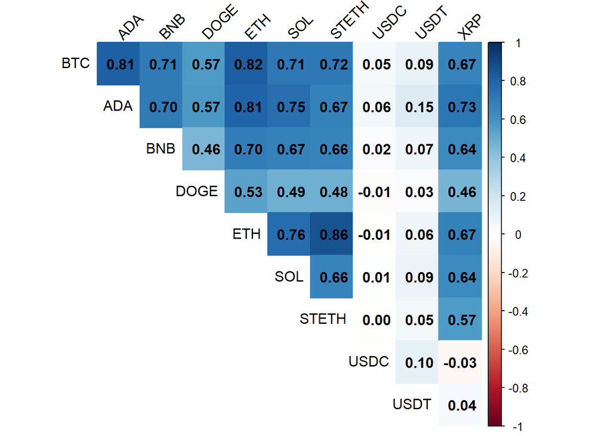

```r
corrplot_save("correlation_matrix_sim", cor_function(sim_results$x_sim, df_filtered)$cor_Xsim)
```

## Without Stable Coins…..

```r
target_cols <- c("Close_BTC", "Close_ADA", "Close_BNB", "Close_DOGE",
                 "Close_ETH", "Close_SOL", "Close_STETH", "Close_XRP")

df_8assets <- df_filtered[, target_cols]
```

```r
colnames(df_8assets)
```

```
## [1] "Close_BTC"   "Close_ADA"   "Close_BNB"   "Close_DOGE"  "Close_ETH"
## [6] "Close_SOL"   "Close_STETH" "Close_XRP"
```

```r
go_optim_8a = gogarch_optim(go_garch_conditions, df_8assets)
```

[output not shown]

```r
fits_8a = go_optim_8a$fits
```

```r
go_optim_8a$result_top10
```

```
##    p q mean_model     ica  dist       ll       AIC LB_raw_pass LB_squared_pass
## 51 1 2         AR radical  magh 28885.90 -57659.80           7               8
## 49 1 1         AR radical  magh 28876.71 -57657.41           7               8
## 33 1 2         AR radical manig 28871.67 -57647.33           7               8
## 31 1 1         AR radical manig 28861.23 -57642.46           7               8
## 48 1 2   constant radical  magh 28875.84 -57639.69           7               8
## 46 1 1   constant radical  magh 28867.07 -57638.14           7               8
## 50 2 1         AR radical  magh 28872.19 -57632.38           7               8
## 30 1 2   constant radical manig 28861.05 -57626.10           7               8
## 28 1 1   constant radical manig 28851.35 -57622.71           7               8
## 32 2 1         AR radical manig 28857.03 -57618.06           7               8
```

```r
best_model_8a = fits_8a[[49]]
```

```r
lb_test(best_model_8a, df_8assets)
```

```
##            Factor     LB_raw        p_raw  LB_squared p_squared
## X-squared       1  19.078626 5.167206e-01 12.35699950 0.9032405
## X-squared1      2  10.613414 9.556386e-01  0.04767427 1.0000000
## X-squared2      3  31.536163 4.849850e-02 23.85847057 0.2486292
## X-squared3      4   7.676817 9.937991e-01  0.45002800 1.0000000
## X-squared4      5  23.717484 2.549509e-01 10.89343470 0.9489394
## X-squared5      6  14.935879 7.800648e-01 14.58962418 0.7993882
## X-squared6      7  25.533975 1.817606e-01 19.38183219 0.4971455
## X-squared7      8 116.863448 1.110223e-15  5.27982619 0.9995778
```

```r
#fits_8a = go_optim_8a$fits
sim_results_8a = ggvc_sim(best_model_8a, df_8assets)
cor_function(sim_results_8a$x_sim_gogarch, df_8assets)
```

```
## $rmse
## [1] 0.07036727
##
## $mae
## [1] 0.06088035
##
## $cor_Xsim
##           [,1]      [,2]      [,3]      [,4]      [,5]      [,6]      [,7]
## [1,] 1.0000000 0.7407060 0.6039801 0.4727707 0.8489082 0.4806793 0.8454479
## [2,] 0.7407060 1.0000000 0.6459891 0.4303431 0.7644199 0.5094025 0.7613199
## [3,] 0.6039801 0.6459891 1.0000000 0.2637927 0.6651117 0.5170162 0.6589021
## [4,] 0.4727707 0.4303431 0.2637927 1.0000000 0.4331758 0.2670284 0.4379831
## [5,] 0.8489082 0.7644199 0.6651117 0.4331758 1.0000000 0.5399297 0.9970750
## [6,] 0.4806793 0.5094025 0.5170162 0.2670284 0.5399297 1.0000000 0.5302434
## [7,] 0.8454479 0.7613199 0.6589021 0.4379831 0.9970750 0.5302434 1.0000000
## [8,] 0.4690540 0.6028713 0.3962365 0.2837311 0.4820542 0.3599685 0.4910541
##           [,8]
## [1,] 0.4690540
## [2,] 0.6028713
## [3,] 0.3962365
## [4,] 0.2837311
## [5,] 0.4820542
## [6,] 0.3599685
## [7,] 0.4910541
## [8,] 1.0000000
##
## $cor_Xraw
##             Close_BTC Close_ADA Close_BNB Close_DOGE Close_ETH Close_SOL
## Close_BTC   1.0000000 0.6670262 0.6593282  0.4976296 0.8166491 0.5862155
## Close_ADA   0.6670262 1.0000000 0.5921383  0.4379117 0.6911339 0.5693800
## Close_BNB   0.6593282 0.5921383 1.0000000  0.3420034 0.6779671 0.5767731
## Close_DOGE  0.4976296 0.4379117 0.3420034  1.0000000 0.4625827 0.3506302
## Close_ETH   0.8166491 0.6911339 0.6779671  0.4625827 1.0000000 0.6392459
## Close_SOL   0.5862155 0.5693800 0.5767731  0.3506302 0.6392459 1.0000000
## Close_STETH 0.8015130 0.6701206 0.6678380  0.4527456 0.9811948 0.6231769
## Close_XRP   0.5663595 0.5878209 0.5234890  0.3391238 0.5797220 0.4791898
##             Close_STETH Close_XRP
## Close_BTC     0.8015130 0.5663595
## Close_ADA     0.6701206 0.5878209
## Close_BNB     0.6678380 0.5234890
## Close_DOGE    0.4527456 0.3391238
## Close_ETH     0.9811948 0.5797220
## Close_SOL     0.6231769 0.4791898
## Close_STETH   1.0000000 0.5666549
## Close_XRP     0.5666549 1.0000000
```

```r
cor_function(sim_results_8a$x_sim, df_8assets)
```

```
## $rmse
## [1] 0.2085301
##
## $mae
## [1] 0.1897563
##
## $cor_Xsim
##           [,1]      [,2]      [,3]      [,4]      [,5]      [,6]      [,7]
## [1,] 1.0000000 0.8295078 0.8324808 0.7221167 0.8381167 0.8298825 0.8329878
## [2,] 0.8295078 1.0000000 0.8169304 0.7197885 0.8263034 0.8434405 0.8210622
## [3,] 0.8324808 0.8169304 1.0000000 0.6828654 0.8490032 0.8330139 0.8452588
## [4,] 0.7221167 0.7197885 0.6828654 1.0000000 0.7068728 0.7038576 0.7038556
## [5,] 0.8381167 0.8263034 0.8490032 0.7068728 1.0000000 0.8704774 0.9960603
## [6,] 0.8298825 0.8434405 0.8330139 0.7038576 0.8704774 1.0000000 0.8658976
## [7,] 0.8329878 0.8210622 0.8452588 0.7038556 0.9960603 0.8658976 1.0000000
## [8,] 0.6703300 0.7461731 0.6916627 0.6137769 0.6722307 0.6849294 0.6698573
##           [,8]
## [1,] 0.6703300
## [2,] 0.7461731
## [3,] 0.6916627
## [4,] 0.6137769
## [5,] 0.6722307
## [6,] 0.6849294
## [7,] 0.6698573
## [8,] 1.0000000
##
## $cor_Xraw
##             Close_BTC Close_ADA Close_BNB Close_DOGE Close_ETH Close_SOL
## Close_BTC   1.0000000 0.6670262 0.6593282  0.4976296 0.8166491 0.5862155
## Close_ADA   0.6670262 1.0000000 0.5921383  0.4379117 0.6911339 0.5693800
## Close_BNB   0.6593282 0.5921383 1.0000000  0.3420034 0.6779671 0.5767731
## Close_DOGE  0.4976296 0.4379117 0.3420034  1.0000000 0.4625827 0.3506302
## Close_ETH   0.8166491 0.6911339 0.6779671  0.4625827 1.0000000 0.6392459
## Close_SOL   0.5862155 0.5693800 0.5767731  0.3506302 0.6392459 1.0000000
## Close_STETH 0.8015130 0.6701206 0.6678380  0.4527456 0.9811948 0.6231769
## Close_XRP   0.5663595 0.5878209 0.5234890  0.3391238 0.5797220 0.4791898
##             Close_STETH Close_XRP
## Close_BTC     0.8015130 0.5663595
## Close_ADA     0.6701206 0.5878209
## Close_BNB     0.6678380 0.5234890
## Close_DOGE    0.4527456 0.3391238
## Close_ETH     0.9811948 0.5797220
## Close_SOL     0.6231769 0.4791898
## Close_STETH   1.0000000 0.5666549
## Close_XRP     0.5666549 1.0000000
```

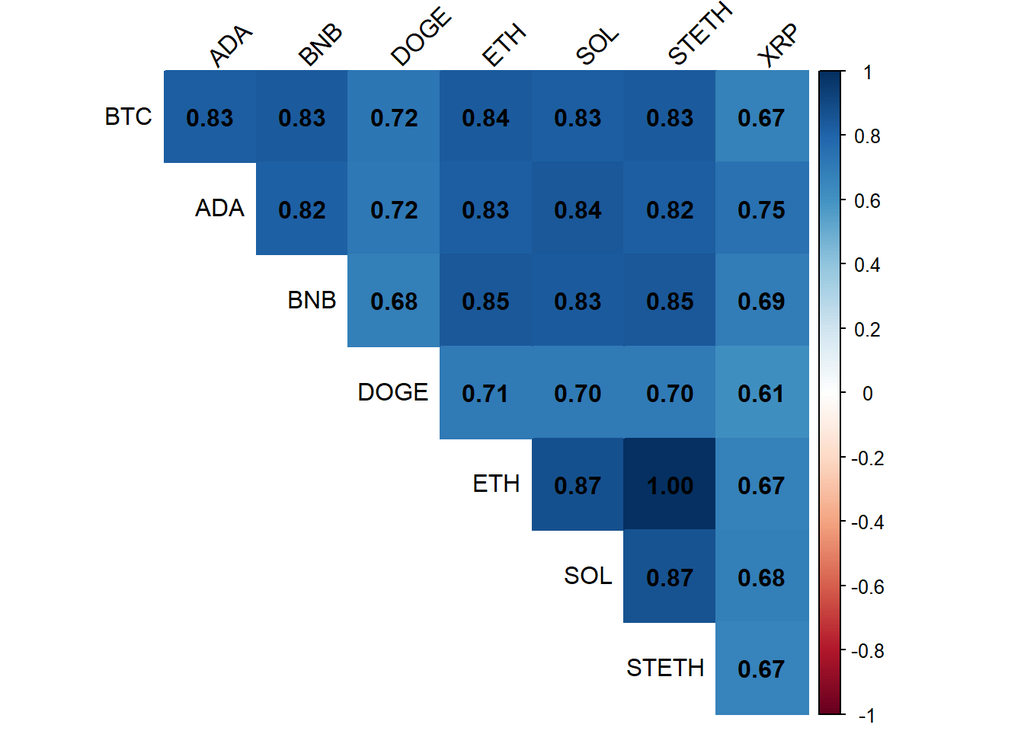

```r
asset_8 = c("BTC", "ADA", "BNB", "DOGE", "ETH", "SOL", "STETH", "XRP")

corrplot_save("correlation_matrix_df_8a_sim",
              cor_function(sim_results_8a$x_sim, df_8assets)$cor_Xsim,
              asset_name =asset_8)
```

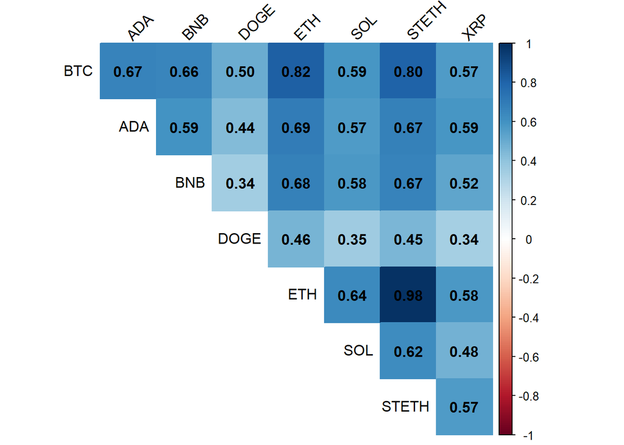

```r
corrplot_save("correlation_matrix_df_8a_raw",
              cor_function(sim_results_8a$x_sim, df_8assets)$cor_Xraw,
              asset_name =asset_8)
```

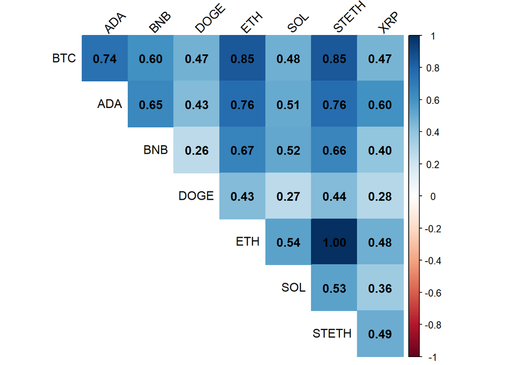

```r
corrplot_save("correlation_matrix_df_8a_gogarchsim",
              cor_function(sim_results_8a$x_sim_gogarch, df_8assets)$cor_Xsim,
              asset_name =asset_8)
```

## Market Stress Period

```r
dates <- as.Date(rownames(df_filtered))

df_pre    <- df_filtered[dates >= as.Date("2020-12-24") & dates <= as.Date("2021-04-02"), ]
df_cri <- df_filtered[dates >= as.Date("2021-03-25") & dates <= as.Date("2021-07-05"), ]
df_pos   <- df_filtered[dates >= as.Date("2021-07-01") & dates <= as.Date("2021-10-31"), ]
```

```r
go_optim_pre = gogarch_optim(go_garch_conditions[49,], df_pre)
lb_test(go_optim_pre$fits[[1]], df_pre)
```

```
##            Factor    LB_raw       p_raw LB_squared p_squared
## X-squared       1  5.083792 0.999684470  0.3996716 1.0000000
## X-squared1      2 19.356392 0.498780430 24.3215799 0.2286271
## X-squared2      3 10.606717 0.955791081  4.7698108 0.9998082
## X-squared3      4 18.835834 0.532518929 14.8979385 0.7822175
## X-squared4      5 28.991782 0.087921298 24.2840895 0.2302028
## X-squared5      6 14.651959 0.795964169  7.6242019 0.9940764
## X-squared6      7 11.454862 0.933563273 11.2034422 0.9407750
## X-squared7      8 37.771562 0.009442069 26.7460862 0.1425600
## X-squared8      9 39.570565 0.005658091 18.1011067 0.5807479
## X-squared9     10 30.487906 0.062324209  2.4362778 0.9999993
```

```r
sim_results_pre = ggvc_sim(go_optim_pre$fits[[1]], df_pre)
cor_function(sim_results_pre$x_sim_gogarch, df_pre)
```

```
## $rmse
## [1] 0.3328029
##
## $mae
## [1] 0.2485037
##
## $cor_Xsim
##              [,1]        [,2]        [,3]         [,4]        [,5]        [,6]
##  [1,]  1.00000000  0.26441939  0.57425576  0.036861008  0.93895498  0.04943850
##  [2,]  0.26441939  1.00000000  0.18268272  0.078803185  0.27830105 -0.82156043
##  [3,]  0.57425576  0.18268272  1.00000000 -0.054110967  0.46661908  0.33695289
##  [4,]  0.03686101  0.07880318 -0.05411097  1.000000000 -0.13444523 -0.04119675
##  [5,]  0.93895498  0.27830105  0.46661908 -0.134445231  1.00000000 -0.08769875
##  [6,]  0.04943850 -0.82156043  0.33695289 -0.041196746 -0.08769875  1.00000000
##  [7,]  0.89495100  0.20006271  0.34026395 -0.177427555  0.94940703 -0.01940764
##  [8,] -0.59837061  0.09350985 -0.06757255  0.259554039 -0.61553683 -0.19896682
##  [9,] -0.64153862  0.11873511 -0.05074497  0.243319640 -0.69681372 -0.15863781
## [10,]  0.22906946 -0.30237527  0.12647248 -0.003200137 -0.03102897  0.47363003
##              [,7]        [,8]        [,9]        [,10]
##  [1,]  0.89495100 -0.59837061 -0.64153862  0.229069463
##  [2,]  0.20006271  0.09350985  0.11873511 -0.302375274
##  [3,]  0.34026395 -0.06757255 -0.05074497  0.126472483
##  [4,] -0.17742755  0.25955404  0.24331964 -0.003200137
##  [5,]  0.94940703 -0.61553683 -0.69681372 -0.031028970
##  [6,] -0.01940764 -0.19896682 -0.15863781  0.473630028
##  [7,]  1.00000000 -0.79786969 -0.83378794 -0.015293888
##  [8,] -0.79786969  1.00000000  0.97174081 -0.116436498
##  [9,] -0.83378794  0.97174081  1.00000000 -0.060976798
## [10,] -0.01529389 -0.11643650 -0.06097680  1.000000000
##
## $cor_Xraw
##               Close_BTC   Close_ADA   Close_BNB  Close_DOGE   Close_ETH
## Close_BTC    1.00000000  0.37074195  0.46008169  0.28926470  0.69084695
## Close_ADA    0.37074195  1.00000000  0.29114712  0.13668220  0.48035118
## Close_BNB    0.46008169  0.29114712  1.00000000  0.02348567  0.38591724
## Close_DOGE   0.28926470  0.13668220  0.02348567  1.00000000  0.17967186
## Close_ETH    0.69084695  0.48035118  0.38591724  0.17967186  1.00000000
## Close_SOL    0.26140482  0.17865409  0.42452108  0.03784701  0.31856586
## Close_STETH  0.69706748  0.43582885  0.36177685  0.19383431  0.96041833
## Close_USDC  -0.17902177 -0.07816047 -0.01580962 -0.02642739 -0.18110453
## Close_USDT  -0.05902534  0.10905457  0.03350866 -0.06673630  0.02297698
## Close_XRP    0.23051916  0.06334231  0.22565278  0.01139468  0.23794791
##                 Close_SOL Close_STETH    Close_USDC   Close_USDT   Close_XRP
## Close_BTC    0.2614048151  0.69706748 -0.1790217689 -0.059025338  0.23051916
## Close_ADA    0.1786540861  0.43582885 -0.0781604713  0.109054565  0.06334231
## Close_BNB    0.4245210750  0.36177685 -0.0158096195  0.033508665  0.22565278
## Close_DOGE   0.0378470084  0.19383431 -0.0264273938 -0.066736302  0.01139468
## Close_ETH    0.3185658569  0.96041833 -0.1811045263  0.022976979  0.23794791
## Close_SOL    1.0000000000  0.27203051 -0.0005611733 -0.000971555  0.30129320
## Close_STETH  0.2720305103  1.00000000 -0.2062611279 -0.050029334  0.22158267
## Close_USDC  -0.0005611733 -0.20626113  1.0000000000  0.386868970 -0.19870980
## Close_USDT  -0.0009715550 -0.05002933  0.3868689704  1.000000000  0.01873370
## Close_XRP    0.3012931987  0.22158267 -0.1987098011  0.018733703  1.00000000
```

```r
cor_function(sim_results_pre$x_sim, df_pre)
```

```
## $rmse
## [1] 0.3469678
##
## $mae
## [1] 0.2344329
##
## $cor_Xsim
##               [,1]        [,2]         [,3]        [,4]       [,5]         [,6]
##  [1,]  1.000000000  0.32514615  0.533070288  0.69172265  0.7565606 -0.004872285
##  [2,]  0.325146148  1.00000000  0.185828458  0.20983564  0.5666104 -0.880221620
##  [3,]  0.533070288  0.18582846  1.000000000  0.08210441  0.5102188  0.181710737
##  [4,]  0.691722647  0.20983564  0.082104412  1.00000000  0.2529487  0.038985764
##  [5,]  0.756560639  0.56661045  0.510218832  0.25294872  1.0000000 -0.436905469
##  [6,] -0.004872285 -0.88022162  0.181710737  0.03898576 -0.4369055  1.000000000
##  [7,]  0.772877860  0.58748570  0.441956213  0.34275588  0.9605821 -0.428783437
##  [8,] -0.314733031  0.10248389 -0.046618012 -0.05275628 -0.2492106 -0.189663950
##  [9,] -0.429015843  0.01615497 -0.044060781 -0.06471758 -0.5634534  0.016345668
## [10,]  0.087810423 -0.65975035 -0.002296705 -0.01094015 -0.4003841  0.762836051
##             [,7]        [,8]        [,9]        [,10]
##  [1,]  0.7728779 -0.31473303 -0.42901584  0.087810423
##  [2,]  0.5874857  0.10248389  0.01615497 -0.659750346
##  [3,]  0.4419562 -0.04661801 -0.04406078 -0.002296705
##  [4,]  0.3427559 -0.05275628 -0.06471758 -0.010940150
##  [5,]  0.9605821 -0.24921055 -0.56345341 -0.400384056
##  [6,] -0.4287834 -0.18966395  0.01634567  0.762836051
##  [7,]  1.0000000 -0.43271583 -0.65492408 -0.415110649
##  [8,] -0.4327158  1.00000000  0.82967043 -0.175289161
##  [9,] -0.6549241  0.82967043  1.00000000  0.051259053
## [10,] -0.4151106 -0.17528916  0.05125905  1.000000000
##
## $cor_Xraw
##               Close_BTC   Close_ADA   Close_BNB  Close_DOGE   Close_ETH
## Close_BTC    1.00000000  0.37074195  0.46008169  0.28926470  0.69084695
## Close_ADA    0.37074195  1.00000000  0.29114712  0.13668220  0.48035118
## Close_BNB    0.46008169  0.29114712  1.00000000  0.02348567  0.38591724
## Close_DOGE   0.28926470  0.13668220  0.02348567  1.00000000  0.17967186
## Close_ETH    0.69084695  0.48035118  0.38591724  0.17967186  1.00000000
## Close_SOL    0.26140482  0.17865409  0.42452108  0.03784701  0.31856586
## Close_STETH  0.69706748  0.43582885  0.36177685  0.19383431  0.96041833
## Close_USDC  -0.17902177 -0.07816047 -0.01580962 -0.02642739 -0.18110453
## Close_USDT  -0.05902534  0.10905457  0.03350866 -0.06673630  0.02297698
## Close_XRP    0.23051916  0.06334231  0.22565278  0.01139468  0.23794791
##                 Close_SOL Close_STETH    Close_USDC   Close_USDT   Close_XRP
## Close_BTC    0.2614048151  0.69706748 -0.1790217689 -0.059025338  0.23051916
## Close_ADA    0.1786540861  0.43582885 -0.0781604713  0.109054565  0.06334231
## Close_BNB    0.4245210750  0.36177685 -0.0158096195  0.033508665  0.22565278
## Close_DOGE   0.0378470084  0.19383431 -0.0264273938 -0.066736302  0.01139468
## Close_ETH    0.3185658569  0.96041833 -0.1811045263  0.022976979  0.23794791
## Close_SOL    1.0000000000  0.27203051 -0.0005611733 -0.000971555  0.30129320
## Close_STETH  0.2720305103  1.00000000 -0.2062611279 -0.050029334  0.22158267
## Close_USDC  -0.0005611733 -0.20626113  1.0000000000  0.386868970 -0.19870980
## Close_USDT  -0.0009715550 -0.05002933  0.3868689704  1.000000000  0.01873370
## Close_XRP    0.3012931987  0.22158267 -0.1987098011  0.018733703  1.00000000
```

```r
#corrplot_save("correlation_matrix_sim", cor_function(sim_results$x_sim, df_filtered)$cor_Xsim)
```

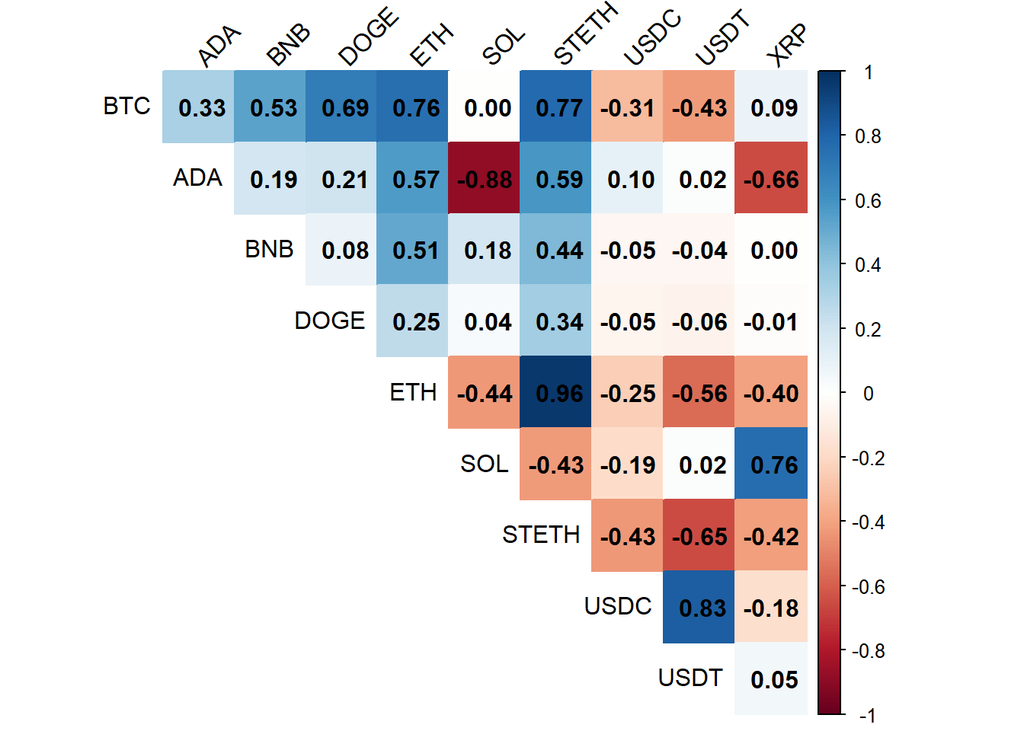

```r
corrplot_save("correlation_matrix_df_pre_sim", cor_function(sim_results_pre$x_sim, df_pre)$cor_Xsim)
```

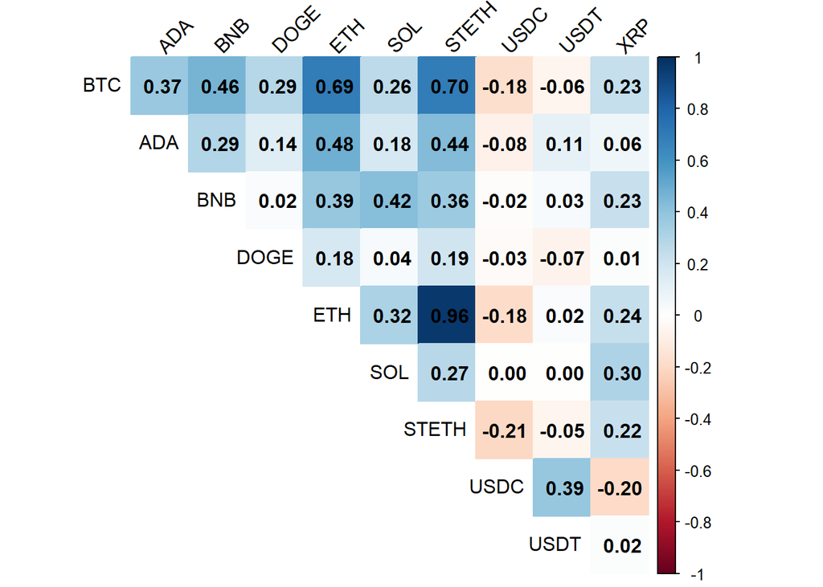

```r
corrplot_save("correlation_matrix_df_pre_raw", cor_function(sim_results_pre$x_sim, df_pre)$cor_Xraw)
```

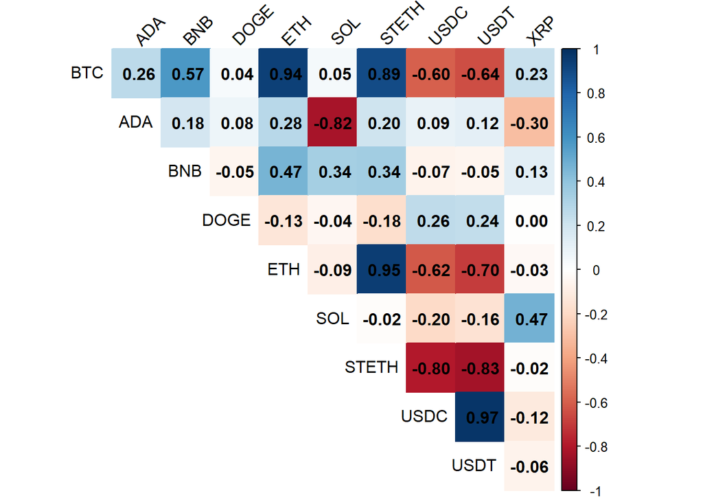

```r
corrplot_save("correlation_matrix_df_pre_gogarchsim", cor_function(sim_results_pre$x_sim_gogarch, df_pre)$cor_Xsim)
```

```r
go_optim_cri = gogarch_optim(go_garch_conditions[49,], df_cri)
lb_test(go_optim_cri$fits[[1]], df_cri)
```

```
##            Factor   LB_raw      p_raw LB_squared  p_squared
## X-squared       1 18.56599 0.55017652   1.288366 1.00000000
## X-squared1      2 22.79449 0.29899783   4.414648 0.99989638
## X-squared2      3 24.30911 0.22915054  28.577134 0.09642580
## X-squared3      4 12.11082 0.91220863   8.128315 0.99098425
## X-squared4      5 18.21975 0.57293494  16.551979 0.68184434
## X-squared5      6 26.36849 0.15398387  17.233707 0.63775008
## X-squared6      7 29.65793 0.07558923  10.024603 0.96772362
## X-squared7      8 32.36525 0.03955853  30.131927 0.06774399
## X-squared8      9 14.07750 0.82654470   1.765047 0.99999996
```

```r
sim_results_cri = ggvc_sim(go_optim_cri$fits[[1]], df_cri)
cor_function(sim_results_cri$x_sim_gogarch, df_cri)
```

```
## $rmse
## [1] 0.09169637
##
## $mae
## [1] 0.0723765
##
## $cor_Xsim
##               [,1]        [,2]        [,3]        [,4]        [,5]        [,6]
##  [1,]  1.000000000  0.73082425  0.73039870  0.36868881  0.76740501  0.38523565
##  [2,]  0.730824248  1.00000000  0.70564724  0.35002045  0.72196176  0.42692513
##  [3,]  0.730398705  0.70564724  1.00000000  0.16190576  0.79474437  0.54402620
##  [4,]  0.368688812  0.35002045  0.16190576  1.00000000  0.34408216  0.13192703
##  [5,]  0.767405005  0.72196176  0.79474437  0.34408216  1.00000000  0.51058239
##  [6,]  0.385235655  0.42692513  0.54402620  0.13192703  0.51058239  1.00000000
##  [7,]  0.756600206  0.70593505  0.81959969  0.32173776  0.99803829  0.51141229
##  [8,] -0.067212359 -0.04143957 -0.01708763 -0.05659317 -0.06935275 -0.07544346
##  [9,]  0.002491252  0.01015419 -0.03076347  0.03381465 -0.02389129 -0.11239789
## [10,]  0.769750635  0.94025435  0.87319020  0.23918308  0.80802858  0.51435127
##              [,7]        [,8]         [,9]       [,10]
##  [1,]  0.75660021 -0.06721236  0.002491252  0.76975063
##  [2,]  0.70593505 -0.04143957  0.010154189  0.94025435
##  [3,]  0.81959969 -0.01708763 -0.030763473  0.87319020
##  [4,]  0.32173776 -0.05659317  0.033814648  0.23918308
##  [5,]  0.99803829 -0.06935275 -0.023891288  0.80802858
##  [6,]  0.51141229 -0.07544346 -0.112397894  0.51435127
##  [7,]  1.00000000 -0.05136223 -0.012207664  0.80674480
##  [8,] -0.05136223  1.00000000  0.986314787 -0.09927760
##  [9,] -0.01220766  0.98631479  1.000000000 -0.07818283
## [10,]  0.80674480 -0.09927760 -0.078182826  1.00000000
##
## $cor_Xraw
##               Close_BTC  Close_ADA  Close_BNB Close_DOGE   Close_ETH  Close_SOL
## Close_BTC   1.000000000 0.76473592 0.76882614  0.4656859  0.79537945  0.5034233
## Close_ADA   0.764735920 1.00000000 0.75453846  0.4496196  0.75513921  0.5740478
## Close_BNB   0.768826141 0.75453846 1.00000000  0.3790423  0.81863228  0.6401439
## Close_DOGE  0.465685934 0.44961961 0.37904229  1.0000000  0.43382779  0.3262877
## Close_ETH   0.795379455 0.75513921 0.81863228  0.4338278  1.00000000  0.6583937
## Close_SOL   0.503423298 0.57404784 0.64014391  0.3262877  0.65839373  1.0000000
## Close_STETH 0.748556477 0.72572166 0.81651224  0.4014244  0.97265900  0.6457886
## Close_USDC  0.007969298 0.01777553 0.05211835 -0.1157756 -0.03299987 -0.1256815
## Close_USDT  0.027581848 0.03511767 0.04151654 -0.1038548 -0.01741059 -0.1433893
## Close_XRP   0.724048916 0.75173567 0.71175474  0.3621103  0.69453405  0.4480373
##             Close_STETH   Close_USDC  Close_USDT   Close_XRP
## Close_BTC    0.74855648  0.007969298  0.02758185  0.72404892
## Close_ADA    0.72572166  0.017775533  0.03511767  0.75173567
## Close_BNB    0.81651224  0.052118353  0.04151654  0.71175474
## Close_DOGE   0.40142438 -0.115775556 -0.10385478  0.36211029
## Close_ETH    0.97265900 -0.032999866 -0.01741059  0.69453405
## Close_SOL    0.64578864 -0.125681528 -0.14338926  0.44803734
## Close_STETH  1.00000000 -0.029103118 -0.01020005  0.66302500
## Close_USDC  -0.02910312  1.000000000  0.97820951 -0.07304663
## Close_USDT  -0.01020005  0.978209511  1.00000000 -0.05251524
## Close_XRP    0.66302500 -0.073046635 -0.05251524  1.00000000
```

```r
cor_function(sim_results_cri$x_sim, df_cri)
```

```
## $rmse
## [1] 0.2629621
##
## $mae
## [1] 0.2018215
##
## $cor_Xsim
##             [,1]        [,2]       [,3]        [,4]       [,5]       [,6]
##  [1,] 1.00000000  0.81361796 0.83081672  0.03156259 0.83252001  0.3429920
##  [2,] 0.81361796  1.00000000 0.81253757 -0.08902302 0.76346866  0.2477222
##  [3,] 0.83081672  0.81253757 1.00000000  0.03299493 0.84973257  0.4276832
##  [4,] 0.03156259 -0.08902302 0.03299493  1.00000000 0.16715985  0.6589167
##  [5,] 0.83252001  0.76346866 0.84973257  0.16715985 1.00000000  0.4796873
##  [6,] 0.34299195  0.24772221 0.42768318  0.65891672 0.47968728  1.0000000
##  [7,] 0.84172572  0.79004577 0.87498629  0.04750405 0.99054242  0.3942337
##  [8,] 0.20583485  0.34580046 0.18678935 -0.77688292 0.05688910 -0.5659563
##  [9,] 0.21404693  0.35480184 0.18984390 -0.80009346 0.06068045 -0.5775934
## [10,] 0.72672868  0.75611876 0.80659627  0.47195132 0.81090762  0.6841414
##             [,7]       [,8]        [,9]      [,10]
##  [1,] 0.84172572  0.2058348  0.21404693  0.7267287
##  [2,] 0.79004577  0.3458005  0.35480184  0.7561188
##  [3,] 0.87498629  0.1867893  0.18984390  0.8065963
##  [4,] 0.04750405 -0.7768829 -0.80009346  0.4719513
##  [5,] 0.99054242  0.0568891  0.06068045  0.8109076
##  [6,] 0.39423375 -0.5659563 -0.57759343  0.6841414
##  [7,] 1.00000000  0.1796288  0.18562816  0.7598601
##  [8,] 0.17962879  1.0000000  0.99745316 -0.2605119
##  [9,] 0.18562816  0.9974532  1.00000000 -0.2665083
## [10,] 0.75986009 -0.2605119 -0.26650833  1.0000000
##
## $cor_Xraw
##               Close_BTC  Close_ADA  Close_BNB Close_DOGE   Close_ETH  Close_SOL
## Close_BTC   1.000000000 0.76473592 0.76882614  0.4656859  0.79537945  0.5034233
## Close_ADA   0.764735920 1.00000000 0.75453846  0.4496196  0.75513921  0.5740478
## Close_BNB   0.768826141 0.75453846 1.00000000  0.3790423  0.81863228  0.6401439
## Close_DOGE  0.465685934 0.44961961 0.37904229  1.0000000  0.43382779  0.3262877
## Close_ETH   0.795379455 0.75513921 0.81863228  0.4338278  1.00000000  0.6583937
## Close_SOL   0.503423298 0.57404784 0.64014391  0.3262877  0.65839373  1.0000000
## Close_STETH 0.748556477 0.72572166 0.81651224  0.4014244  0.97265900  0.6457886
## Close_USDC  0.007969298 0.01777553 0.05211835 -0.1157756 -0.03299987 -0.1256815
## Close_USDT  0.027581848 0.03511767 0.04151654 -0.1038548 -0.01741059 -0.1433893
## Close_XRP   0.724048916 0.75173567 0.71175474  0.3621103  0.69453405  0.4480373
##             Close_STETH   Close_USDC  Close_USDT   Close_XRP
## Close_BTC    0.74855648  0.007969298  0.02758185  0.72404892
## Close_ADA    0.72572166  0.017775533  0.03511767  0.75173567
## Close_BNB    0.81651224  0.052118353  0.04151654  0.71175474
## Close_DOGE   0.40142438 -0.115775556 -0.10385478  0.36211029
## Close_ETH    0.97265900 -0.032999866 -0.01741059  0.69453405
## Close_SOL    0.64578864 -0.125681528 -0.14338926  0.44803734
## Close_STETH  1.00000000 -0.029103118 -0.01020005  0.66302500
## Close_USDC  -0.02910312  1.000000000  0.97820951 -0.07304663
## Close_USDT  -0.01020005  0.978209511  1.00000000 -0.05251524
## Close_XRP    0.66302500 -0.073046635 -0.05251524  1.00000000
```

```r
#corrplot_save("correlation_matrix_sim", cor_function(sim_results$x_sim, df_filtered)$cor_Xsim)
```

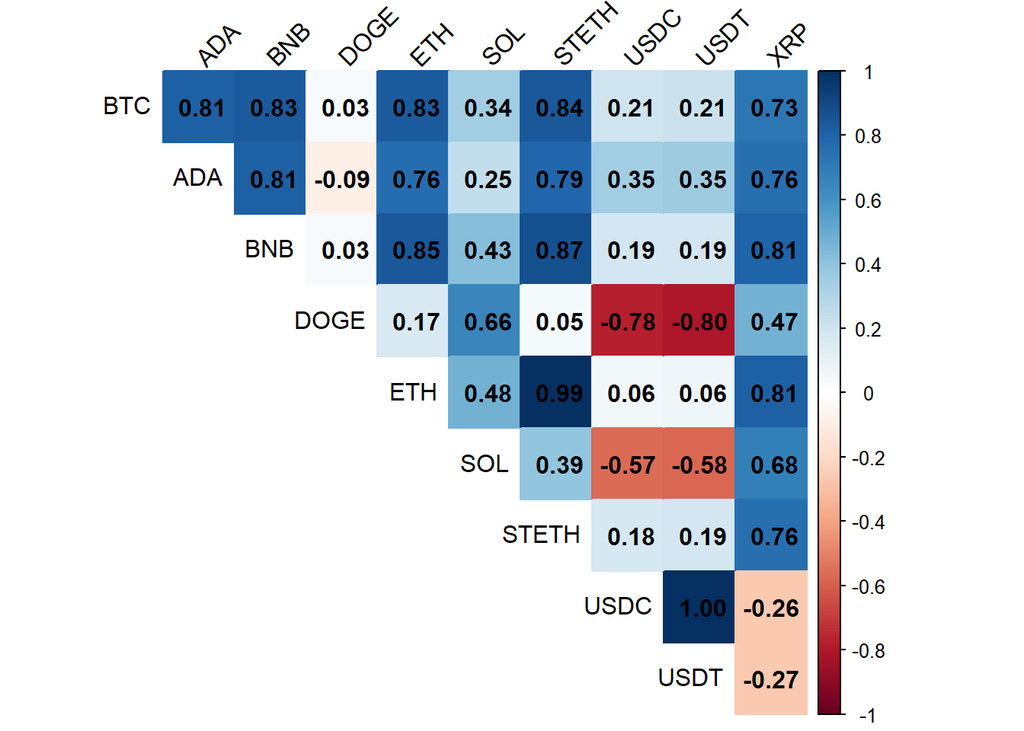

```r
corrplot_save("correlation_matrix_df_cri_sim", cor_function(sim_results_cri$x_sim, df_cri)$cor_Xsim)
```

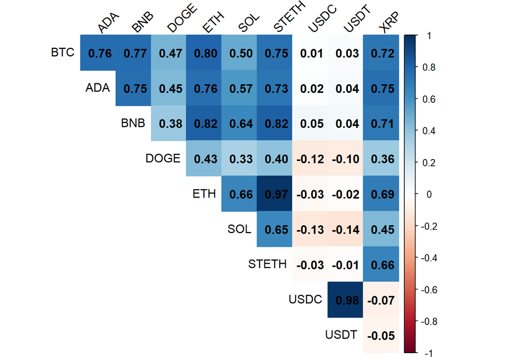

```r
corrplot_save("correlation_matrix_df_cri_raw", cor_function(sim_results_cri$x_sim, df_cri)$cor_Xraw)
```

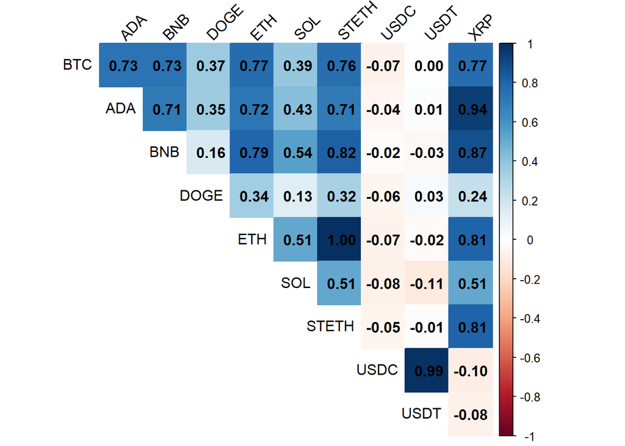

```r
corrplot_save("correlation_matrix_df_cri_gogarchsim", cor_function(sim_results_cri$x_sim_gogarch, df_cri)$cor_Xsim)
```

```r
go_optim_pos = gogarch_optim(go_garch_conditions[49,], df_pos)
lb_test(go_optim_pos$fits[[1]], df_pos)
```

```
##            Factor   LB_raw      p_raw LB_squared  p_squared
## X-squared       1 18.66545 0.54365768  20.165254 0.44763591
## X-squared1      2 17.98942 0.58810547  30.624453 0.06034755
## X-squared2      3 24.69476 0.21335920  14.188873 0.82079190
## X-squared3      4 14.64035 0.79660397   7.797386 0.99312558
## X-squared4      5 24.96581 0.20274236  31.546036 0.04838229
## X-squared5      6 11.83730 0.92156213  13.622451 0.84911117
## X-squared6      7 18.62231 0.54648425  30.092655 0.06836616
## X-squared7      8 32.38772 0.03933818   4.786557 0.99980286
## X-squared8      9 32.72583 0.03615217  12.042469 0.91460646
```

```r
sim_results_pos = ggvc_sim(go_optim_pos$fits[[1]], df_pos)
cor_function(sim_results_pos$x_sim_gogarch, df_pos)
```

```
## $rmse
## [1] 0.1461714
##
## $mae
## [1] 0.1180584
##
## $cor_Xsim
##             [,1]       [,2]       [,3]       [,4]       [,5]       [,6]
##  [1,]  1.0000000  0.6389501  0.7437094  0.7044817  0.8179312  0.5429600
##  [2,]  0.6389501  1.0000000  0.8806433  0.7370698  0.7594338  0.7752866
##  [3,]  0.7437094  0.8806433  1.0000000  0.7876813  0.8468344  0.6933534
##  [4,]  0.7044817  0.7370698  0.7876813  1.0000000  0.8070165  0.6192425
##  [5,]  0.8179312  0.7594338  0.8468344  0.8070165  1.0000000  0.6507664
##  [6,]  0.5429600  0.7752866  0.6933534  0.6192425  0.6507664  1.0000000
##  [7,]  0.7779407  0.6143237  0.7724733  0.7443785  0.9143562  0.5425127
##  [8,] -0.5176253 -0.3305703 -0.3810763 -0.3530089 -0.4192863 -0.3759961
##  [9,] -0.3600677 -0.1768636 -0.2282382 -0.1765864 -0.2296206 -0.2641269
## [10,]  0.7115415  0.9276130  0.8824716  0.8007194  0.8008246  0.7111925
##             [,7]       [,8]       [,9]      [,10]
##  [1,]  0.7779407 -0.5176253 -0.3600677  0.7115415
##  [2,]  0.6143237 -0.3305703 -0.1768636  0.9276130
##  [3,]  0.7724733 -0.3810763 -0.2282382  0.8824716
##  [4,]  0.7443785 -0.3530089 -0.1765864  0.8007194
##  [5,]  0.9143562 -0.4192863 -0.2296206  0.8008246
##  [6,]  0.5425127 -0.3759961 -0.2641269  0.7111925
##  [7,]  1.0000000 -0.3829224 -0.2194514  0.6951291
##  [8,] -0.3829224  1.0000000  0.9740941 -0.3971576
##  [9,] -0.2194514  0.9740941  1.0000000 -0.2231643
## [10,]  0.6951291 -0.3971576 -0.2231643  1.0000000
##
## $cor_Xraw
##              Close_BTC   Close_ADA  Close_BNB Close_DOGE  Close_ETH  Close_SOL
## Close_BTC    1.0000000  0.62383475  0.7230184  0.6679961  0.8216097  0.3513591
## Close_ADA    0.6238348  1.00000000  0.7020958  0.6030500  0.6716449  0.4186551
## Close_BNB    0.7230184  0.70209582  1.0000000  0.6545263  0.7885080  0.3820271
## Close_DOGE   0.6679961  0.60304999  0.6545263  1.0000000  0.7298873  0.3773904
## Close_ETH    0.8216097  0.67164487  0.7885080  0.7298873  1.0000000  0.4666649
## Close_SOL    0.3513591  0.41865512  0.3820271  0.3773904  0.4666649  1.0000000
## Close_STETH  0.7950224  0.62860757  0.7836795  0.7030245  0.9588484  0.4534186
## Close_USDC  -0.3461268 -0.20867017 -0.2630339 -0.3124065 -0.3283838 -0.2041393
## Close_USDT  -0.1482890 -0.04544491 -0.1087714 -0.1344033 -0.1061290 -0.1229594
## Close_XRP    0.6952525  0.75799272  0.7103518  0.6882552  0.7249211  0.3490313
##             Close_STETH Close_USDC  Close_USDT   Close_XRP
## Close_BTC    0.79502244 -0.3461268 -0.14828901  0.69525251
## Close_ADA    0.62860757 -0.2086702 -0.04544491  0.75799272
## Close_BNB    0.78367951 -0.2630339 -0.10877137  0.71035180
## Close_DOGE   0.70302451 -0.3124065 -0.13440329  0.68825524
## Close_ETH    0.95884841 -0.3283838 -0.10612902  0.72492113
## Close_SOL    0.45341859 -0.2041393 -0.12295938  0.34903133
## Close_STETH  1.00000000 -0.3041528 -0.09999987  0.71739473
## Close_USDC  -0.30415276  1.0000000  0.80014912 -0.27364357
## Close_USDT  -0.09999987  0.8001491  1.00000000 -0.06931162
## Close_XRP    0.71739473 -0.2736436 -0.06931162  1.00000000
```

```r
cor_function(sim_results_pos$x_sim, df_pos)
```

```
## $rmse
## [1] 0.06966798
##
## $mae
## [1] 0.05631349
##
## $cor_Xsim
##             [,1]        [,2]       [,3]       [,4]       [,5]       [,6]
##  [1,]  1.0000000  0.50670045  0.6681123  0.6208525  0.8002612  0.3770438
##  [2,]  0.5067005  1.00000000  0.7053451  0.5499526  0.5960511  0.4644594
##  [3,]  0.6681123  0.70534513  1.0000000  0.6176831  0.7249512  0.3833367
##  [4,]  0.6208525  0.54995257  0.6176831  1.0000000  0.6531919  0.4004807
##  [5,]  0.8002612  0.59605107  0.7249512  0.6531919  1.0000000  0.4137806
##  [6,]  0.3770438  0.46445937  0.3833367  0.4004807  0.4137806  1.0000000
##  [7,]  0.7579205  0.55209825  0.7362639  0.6377198  0.8757798  0.3765370
##  [8,] -0.4505503 -0.18171347 -0.2679500 -0.2981504 -0.3025368 -0.3068331
##  [9,] -0.3129347 -0.08043101 -0.1693475 -0.1672065 -0.1393995 -0.2506312
## [10,]  0.6095469  0.76219906  0.7066391  0.6544431  0.6333122  0.3768977
##             [,7]       [,8]        [,9]      [,10]
##  [1,]  0.7579205 -0.4505503 -0.31293466  0.6095469
##  [2,]  0.5520982 -0.1817135 -0.08043101  0.7621991
##  [3,]  0.7362639 -0.2679500 -0.16934748  0.7066391
##  [4,]  0.6377198 -0.2981504 -0.16720650  0.6544431
##  [5,]  0.8757798 -0.3025368 -0.13939955  0.6333122
##  [6,]  0.3765370 -0.3068331 -0.25063119  0.3768977
##  [7,]  1.0000000 -0.2795965 -0.14921213  0.6159611
##  [8,] -0.2795965  1.0000000  0.98108158 -0.2928704
##  [9,] -0.1492121  0.9810816  1.00000000 -0.1634753
## [10,]  0.6159611 -0.2928704 -0.16347525  1.0000000
##
## $cor_Xraw
##              Close_BTC   Close_ADA  Close_BNB Close_DOGE  Close_ETH  Close_SOL
## Close_BTC    1.0000000  0.62383475  0.7230184  0.6679961  0.8216097  0.3513591
## Close_ADA    0.6238348  1.00000000  0.7020958  0.6030500  0.6716449  0.4186551
## Close_BNB    0.7230184  0.70209582  1.0000000  0.6545263  0.7885080  0.3820271
## Close_DOGE   0.6679961  0.60304999  0.6545263  1.0000000  0.7298873  0.3773904
## Close_ETH    0.8216097  0.67164487  0.7885080  0.7298873  1.0000000  0.4666649
## Close_SOL    0.3513591  0.41865512  0.3820271  0.3773904  0.4666649  1.0000000
## Close_STETH  0.7950224  0.62860757  0.7836795  0.7030245  0.9588484  0.4534186
## Close_USDC  -0.3461268 -0.20867017 -0.2630339 -0.3124065 -0.3283838 -0.2041393
## Close_USDT  -0.1482890 -0.04544491 -0.1087714 -0.1344033 -0.1061290 -0.1229594
## Close_XRP    0.6952525  0.75799272  0.7103518  0.6882552  0.7249211  0.3490313
##             Close_STETH Close_USDC  Close_USDT   Close_XRP
## Close_BTC    0.79502244 -0.3461268 -0.14828901  0.69525251
## Close_ADA    0.62860757 -0.2086702 -0.04544491  0.75799272
## Close_BNB    0.78367951 -0.2630339 -0.10877137  0.71035180
## Close_DOGE   0.70302451 -0.3124065 -0.13440329  0.68825524
## Close_ETH    0.95884841 -0.3283838 -0.10612902  0.72492113
## Close_SOL    0.45341859 -0.2041393 -0.12295938  0.34903133
## Close_STETH  1.00000000 -0.3041528 -0.09999987  0.71739473
## Close_USDC  -0.30415276  1.0000000  0.80014912 -0.27364357
## Close_USDT  -0.09999987  0.8001491  1.00000000 -0.06931162
## Close_XRP    0.71739473 -0.2736436 -0.06931162  1.00000000
```

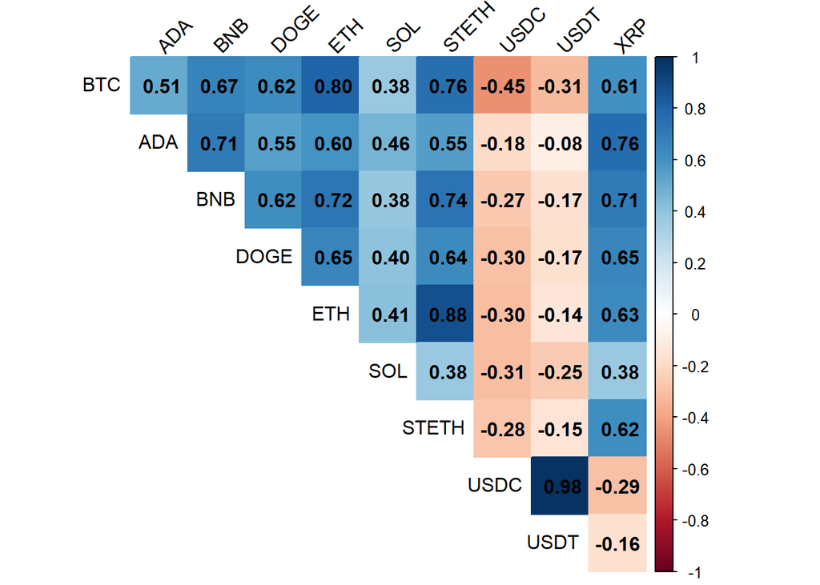

```r
corrplot_save("correlation_matrix_df_post_sim", cor_function(sim_results_pos$x_sim, df_pos)$cor_Xsim)
```

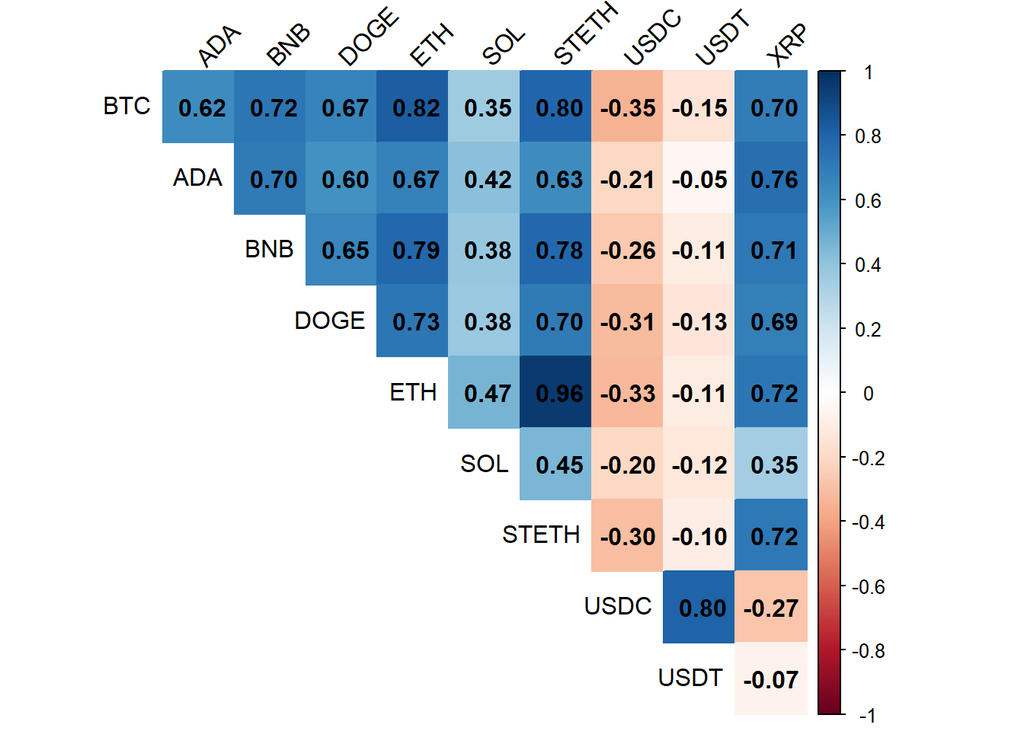

```r
corrplot_save("correlation_matrix_df_post_raw", cor_function(sim_results_pos$x_sim, df_pos)$cor_Xraw)
```

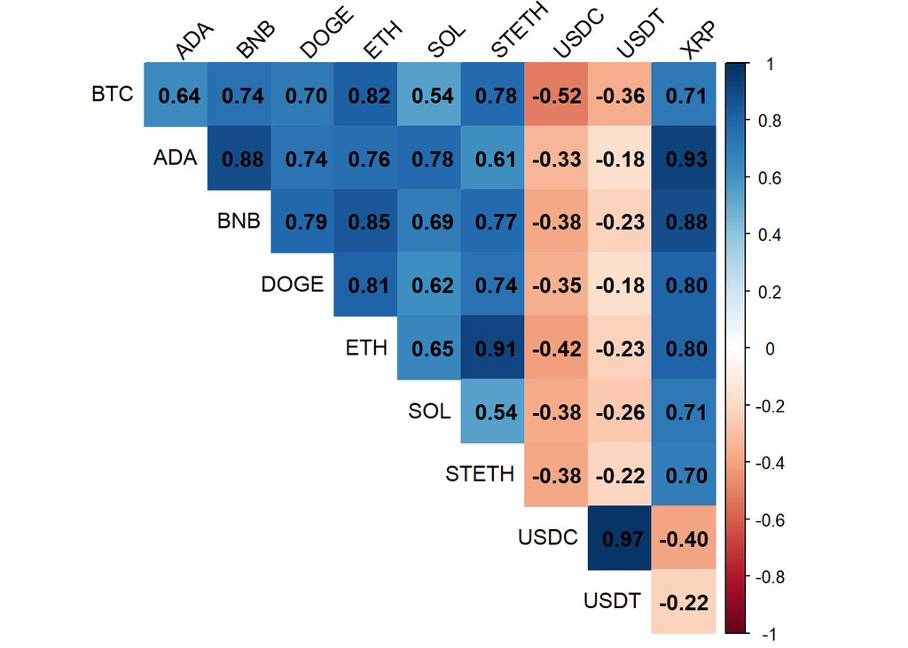

```r
corrplot_save("correlation_matrix_df_post_gogarchsim", cor_function(sim_results_pos$x_sim_gogarch, df_pos)$cor_Xsim)
```

# Weighted sum

```r
mental_crush = (exp(df_filtered)-1) %*% w
```

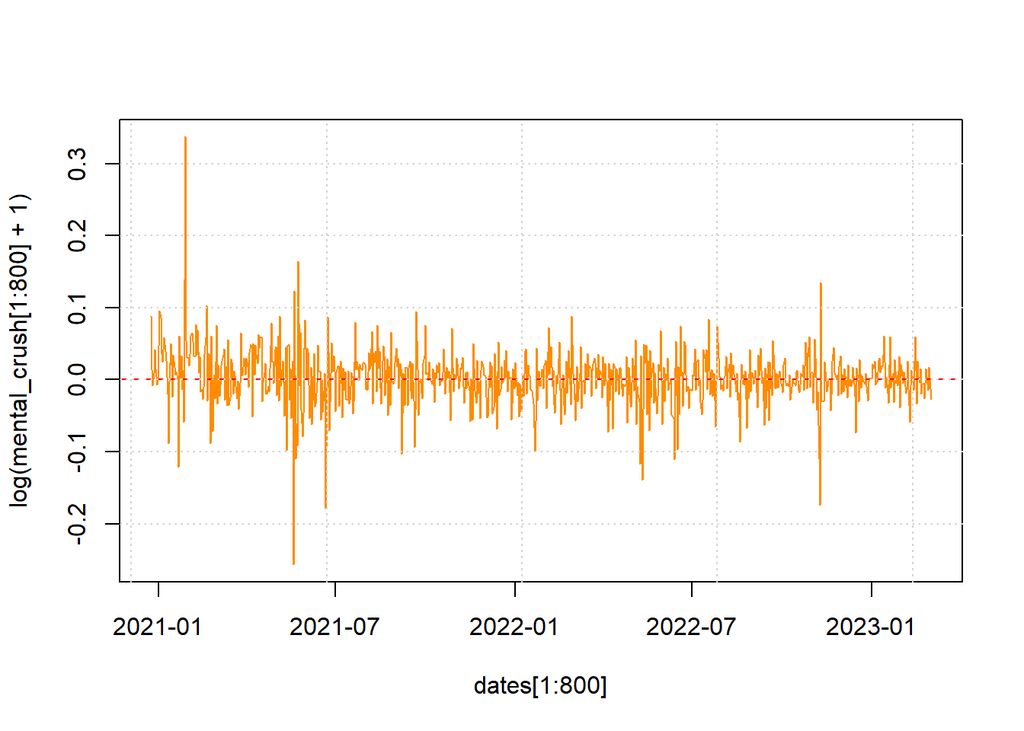

```r
plot(dates[1:800], log(mental_crush[1:800]+1), type = "l", col = "darkorange")
abline(h = 0, col = "red", lty = 2)
grid(nx = NULL, ny = NULL, col = "lightgray", lty = "dotted", lwd = 1)
```

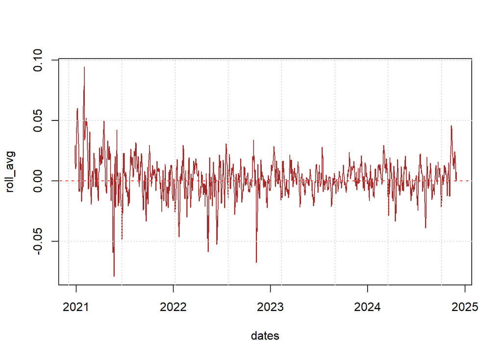

```r
roll_avg <- zoo::rollapply(
  log(mental_crush+1),
  width = 5,
  FUN = mean,
  fill = NA,
  align = "right"
)

plot(dates, roll_avg, type='l', col="brown")
abline(h = 0, col = "red", lty = 2)
grid(nx = NULL, ny = NULL, col = "lightgray", lty = "dotted", lwd = 1)
```

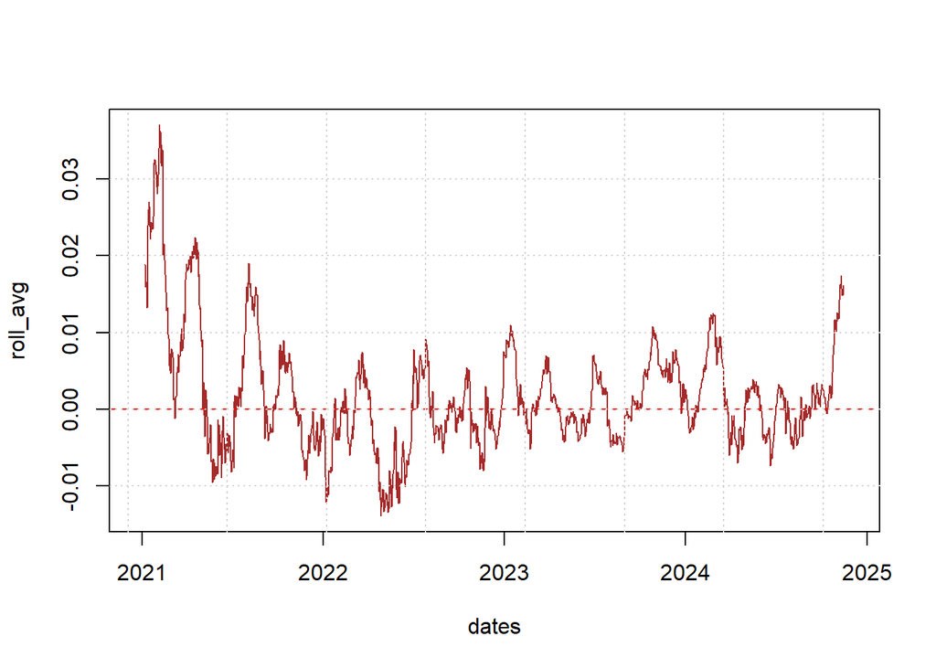

```r
roll_avg <- zoo::rollapply(
  log(mental_crush+1),
  width = 30,
  FUN = mean,
  fill = NA,
  align = "center"
)

plot(dates, roll_avg, type='l', col="brown")
abline(h = 0, col = "red", lty = 2)
grid(nx = NULL, ny = NULL, col = "lightgray", lty = "dotted", lwd = 1)
```

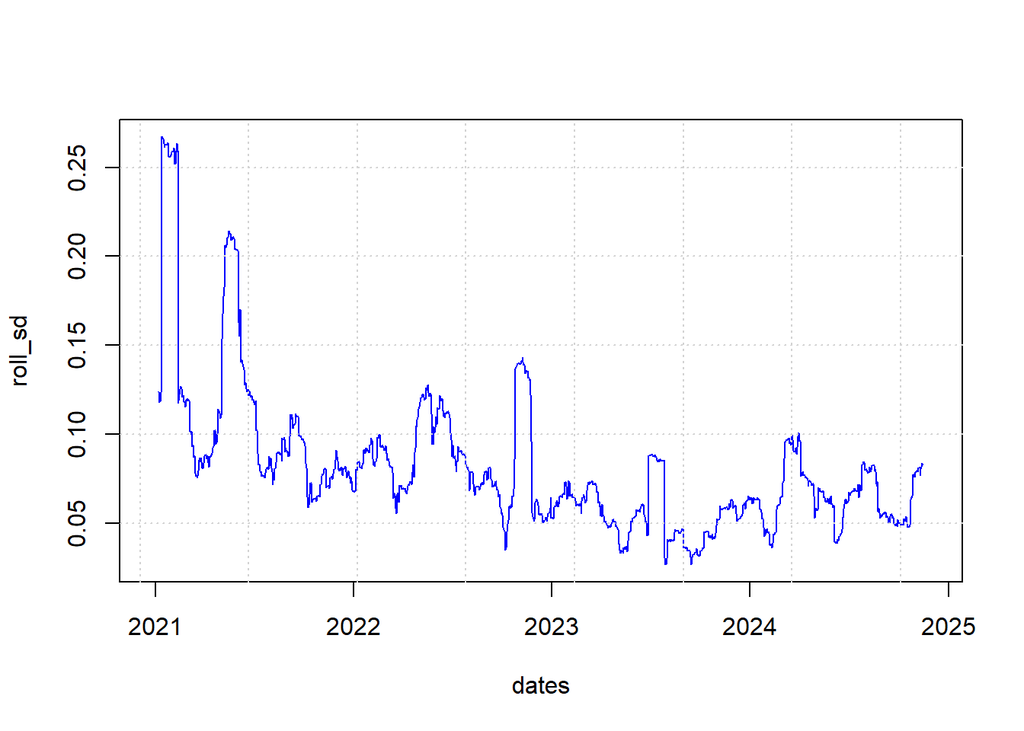

```r
roll_sd <- zoo::rollapply(
  exp(mental_crush+1),
  width = 30,
  FUN = sd,
  fill = NA,
  align = "center"
)

plot(dates, roll_sd, type='l', col="blue")
grid(nx = NULL, ny = NULL, col = "lightgray", lty = "dotted", lwd = 1)
```

2021 H1 High-volatility

2022 Q1 Pre-bust  
2022 Q2 Crisis/bust  
2022 Q3-Q4 Post-crisis

# Additional Test based on Market Situations

```r
dates <- as.Date(rownames(df_filtered))

# 1. High-volatility period (2021 H1)
df_highvol <- df_filtered[
  dates >= as.Date("2020-12-24") &
  dates <= as.Date("2021-06-30"),
]

# 2. Pre-bust period (2022 Q1)
df_prebust <- df_filtered[
  dates >= as.Date("2021-12-20") &
  dates <= as.Date("2022-04-08"),
]

# 3. Crisis / Bust period (2022 Q2)
df_crisis <- df_filtered[
  dates >= as.Date("2022-03-25") &
  dates <= as.Date("2022-07-08"),
]

# 4. Post-crisis / prolonged-stress period (2022 Q3-Q4)
df_postcrisis <- df_filtered[
  dates >= as.Date("2022-06-24") &
  dates <= as.Date("2022-12-31"),
]
```

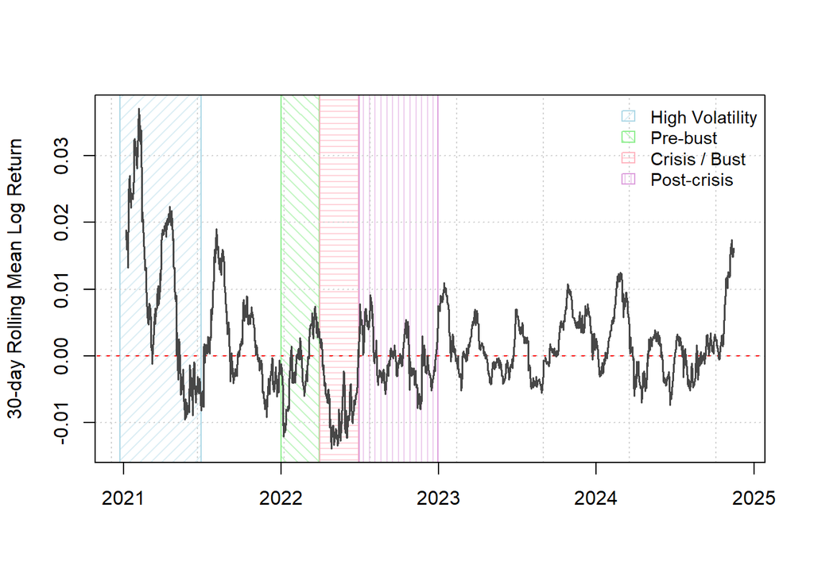

```r
plot(
  dates, roll_avg,
  type = "n",
  xlab = "",
  ylab = "30-day Rolling Mean Log Return"
)

# pastel background
usr <- par("usr")

# 1. High-volatility period
rect(
  as.Date("2020-12-24"), usr[3],
  as.Date("2021-06-30"), usr[4],
  col = adjustcolor("lightblue", alpha.f = 0.4),
  density = 15,
  angle = 45,
  border = "lightblue"
)

# 2. Pre-bust period
rect(
  as.Date("2022-01-01"), usr[3],
  as.Date("2022-03-30"), usr[4],
  col = adjustcolor("lightgreen", alpha.f = 0.5),
  density = 15,
  angle = -45,
  border = "lightgreen"
)

# 3. Crisis / Bust period
rect(
  as.Date("2022-04-01"), usr[3],
  as.Date("2022-06-30"), usr[4],
  col = adjustcolor("lightpink", alpha.f = 0.6),
  density = 20,
  angle = 0,
  border = "lightpink"
)

# 4. Post-crisis / prolonged stress
rect(
  as.Date("2022-07-01"), usr[3],
  as.Date("2022-12-31"), usr[4],
  col = adjustcolor("plum", alpha.f = 0.5),
  density = 20,
  angle = 90,
  border = "plum"
)

# rolling average
lines(
  dates, roll_avg,
  col = "gray28",
  lwd = 1.5
)

# zero line
abline(
  h = 0,
  col = "red",
  lty = 2
)

grid(
  nx = NULL,
  ny = NULL,
  col = "lightgray",
  lty = "dotted",
  lwd = 1
)

# Legend
legend(
  "topright",
  legend = c(
    "High Volatility",
    "Pre-bust",
    "Crisis / Bust",
    "Post-crisis"
  ),
  fill = c(
    adjustcolor("lightblue", alpha.f = 0.4),
    adjustcolor("lightgreen", alpha.f = 0.5),
    adjustcolor("lightpink", alpha.f = 0.6),
    adjustcolor("plum", alpha.f = 0.5)
  ),
  density = c(15, 15, 20, 20),
  angle = c(45, -45, 0, 90),
  border = c("lightblue", "lightgreen", "lightpink", "plum"),
  bty = "n",
  cex = 0.9
)

lines(
  dates, roll_avg,
  col = "gray28",
  lwd = 1.5
)

box()
```

```r
pdf(
  "plots/market_periods_rolling_return.pdf",
  width = 8,
  height = 4.8
)


plot(
  dates, roll_avg,
  type = "n",
  xlab = "",
  ylab = "30-day Rolling Mean Log Return"
)

# pastel background
usr <- par("usr")

# 1. High-volatility period
rect(
  as.Date("2020-12-24"), usr[3],
  as.Date("2021-06-30"), usr[4],
  col = adjustcolor("lightblue", alpha.f = 0.4),
  density = 15,
  angle = 45,
  border = "lightblue"
)

# 2. Pre-bust period
rect(
  as.Date("2022-01-01"), usr[3],
  as.Date("2022-03-30"), usr[4],
  col = adjustcolor("lightgreen", alpha.f = 0.5),
  density = 15,
  angle = -45,
  border = "lightgreen"
)

# 3. Crisis / Bust period
rect(
  as.Date("2022-04-01"), usr[3],
  as.Date("2022-06-30"), usr[4],
  col = adjustcolor("lightpink", alpha.f = 0.6),
  density = 20,
  angle = 0,
  border = "lightpink"
)

# 4. Post-crisis / prolonged stress
rect(
  as.Date("2022-07-01"), usr[3],
  as.Date("2022-12-31"), usr[4],
  col = adjustcolor("plum", alpha.f = 0.5),
  density = 20,
  angle = 90,
  border = "plum"
)

# rolling average
lines(
  dates, roll_avg,
  col = "gray28",
  lwd = 1.5
)

# zero line
abline(
  h = 0,
  col = "red",
  lty = 2
)

grid(
  nx = NULL,
  ny = NULL,
  col = "lightgray",
  lty = "dotted",
  lwd = 1
)

# Legend
legend(
  "topright",
  legend = c(
    "High Volatility",
    "Pre-bust",
    "Crisis / Bust",
    "Post-crisis"
  ),
  fill = c(
    adjustcolor("lightblue", alpha.f = 0.4),
    adjustcolor("lightgreen", alpha.f = 0.5),
    adjustcolor("lightpink", alpha.f = 0.6),
    adjustcolor("plum", alpha.f = 0.5)
  ),
  density = c(15, 15, 20, 20),
  angle = c(45, -45, 0, 90),
  border = c("lightblue", "lightgreen", "lightpink", "plum"),
  bty = "n",
  cex = 0.9
)


box()
dev.off()
```

```r
pdf(
  "plots/market_periods_rolling_sd.pdf",
  width = 8,
  height = 4.8
)


plot(
  dates, roll_sd,
  type = "n",
  xlab = "",
  ylab = "30-day Rolling SD Log Return"
)

# pastel background
usr <- par("usr")

# 1. High-volatility period
rect(
  as.Date("2020-12-24"), usr[3],
  as.Date("2021-06-30"), usr[4],
  col = adjustcolor("lightblue", alpha.f = 0.4),
  density = 15,
  angle = 45,
  border = "lightblue"
)

# 2. Pre-bust period
rect(
  as.Date("2022-01-01"), usr[3],
  as.Date("2022-03-30"), usr[4],
  col = adjustcolor("lightgreen", alpha.f = 0.5),
  density = 15,
  angle = -45,
  border = "lightgreen"
)

# 3. Crisis / Bust period
rect(
  as.Date("2022-04-01"), usr[3],
  as.Date("2022-06-30"), usr[4],
  col = adjustcolor("lightpink", alpha.f = 0.6),
  density = 20,
  angle = 0,
  border = "lightpink"
)

# 4. Post-crisis / prolonged stress
rect(
  as.Date("2022-07-01"), usr[3],
  as.Date("2022-12-31"), usr[4],
  col = adjustcolor("plum", alpha.f = 0.5),
  density = 20,
  angle = 90,
  border = "plum"
)

# rolling average
lines(
  dates, roll_sd,
  col = "darkblue",
  lwd = 1.5
)

# zero line
abline(
  h = 0,
  col = "red",
  lty = 2
)

grid(
  nx = NULL,
  ny = NULL,
  col = "lightgray",
  lty = "dotted",
  lwd = 1
)

# Legend
legend(
  "topright",
  legend = c(
    "High Volatility",
    "Pre-bust",
    "Crisis / Bust",
    "Post-crisis"
  ),
  fill = c(
    adjustcolor("lightblue", alpha.f = 0.4),
    adjustcolor("lightgreen", alpha.f = 0.5),
    adjustcolor("lightpink", alpha.f = 0.6),
    adjustcolor("plum", alpha.f = 0.5)
  ),
  density = c(15, 15, 20, 20),
  angle = c(45, -45, 0, 90),
  border = c("lightblue", "lightgreen", "lightpink", "plum"),
  bty = "n",
  cex = 0.9
)


box()


dev.off()
```

```r
period_analysis <- function(df, conditions) {

  # 1. GO-GARCH fitting
  go_optim <- gogarch_optim(conditions, df)

  fit <- go_optim$fits[[1]]

  # 2. Ljung-Box test
  lb <- lb_test(fit, df)

  # 3. Simulation
  sim_results <- ggvc_sim(fit, df)

  # 4. Correlation comparison
  cor_gogarch <- cor_function(
    sim_results$x_sim_gogarch,
    df
  )

  cor_vine <- cor_function(
    sim_results$x_sim,
    df
  )

  return(list(
    optim = go_optim,
    fit = fit,
    lb_test = lb,
    simulation = sim_results,
    cor_gogarch = cor_gogarch,
    cor_vine = cor_vine
  ))
}
```

```r
df_list <- list(
  highvol = df_highvol,
  prebust = df_prebust,
  crisis = df_crisis,
  postcrisis = df_postcrisis
)

results <- lapply(
  df_list,
  period_analysis,
  conditions = go_garch_conditions[49, ]
)
#corrplot_save("correlation_matrix_sim", cor_function(sim_results$x_sim, df_filtered)$cor_Xsim)
```

```r
results$highvol$cor_vine$rmse
```

```
## [1] 0.1032767
```

```r
results$highvol$cor_vine$mae
```

```
## [1] 0.07762005
```

```r
results$highvol$cor_gogarch$rmse
```

```
## [1] 0.1997015
```

```r
results$highvol$cor_gogarch$mae
```

```
## [1] 0.1693155
```

```r
results_table <- data.frame(
  Period = c(
    rep("Full Sample", 4),
    rep("High Volatility", 4),
    rep("Pre-bust", 4),
    rep("Crisis", 4),
    rep("Post-crisis", 4)
  ),

  Model = c(
    "GO-GARCH", "GO-GARCH",
    "Vine Copula", "Vine Copula",

    "GO-GARCH", "GO-GARCH",
    "Vine Copula", "Vine Copula",

    "GO-GARCH", "GO-GARCH",
    "Vine Copula", "Vine Copula",

    "GO-GARCH", "GO-GARCH",
    "Vine Copula", "Vine Copula",

    "GO-GARCH", "GO-GARCH",
    "Vine Copula", "Vine Copula"
  ),

  Metric = c(
    "RMSE", "MAE", "RMSE", "MAE",
    "RMSE", "MAE", "RMSE", "MAE",
    "RMSE", "MAE", "RMSE", "MAE",
    "RMSE", "MAE", "RMSE", "MAE",
    "RMSE", "MAE", "RMSE", "MAE"
  ),

  Value = c(
    # Full sample
    cor_function(sim_results$x_sim_gogarch, df_filtered)$rmse,
    cor_function(sim_results$x_sim_gogarch, df_filtered)$mae,
    cor_function(sim_results$x_sim, df_filtered)$rmse,
    cor_function(sim_results$x_sim, df_filtered)$mae,

    # High volatility
    results$highvol$cor_gogarch$rmse,
    results$highvol$cor_gogarch$mae,
    results$highvol$cor_vine$rmse,
    results$highvol$cor_vine$mae,

    # Pre-bust
    results$prebust$cor_gogarch$rmse,
    results$prebust$cor_gogarch$mae,
    results$prebust$cor_vine$rmse,
    results$prebust$cor_vine$mae,

    # Crisis
    results$crisis$cor_gogarch$rmse,
    results$crisis$cor_gogarch$mae,
    results$crisis$cor_vine$rmse,
    results$crisis$cor_vine$mae,

    # Post-crisis
    results$postcrisis$cor_gogarch$rmse,
    results$postcrisis$cor_gogarch$mae,
    results$postcrisis$cor_vine$rmse,
    results$postcrisis$cor_vine$mae
  )
)

results_table
```

```
##             Period       Model Metric      Value
## 1      Full Sample    GO-GARCH   RMSE 0.07944511
## 2      Full Sample    GO-GARCH    MAE 0.05839080
## 3      Full Sample Vine Copula   RMSE 0.08360044
## 4      Full Sample Vine Copula    MAE 0.06438474
## 5  High Volatility    GO-GARCH   RMSE 0.19970152
## 6  High Volatility    GO-GARCH    MAE 0.16931552
## 7  High Volatility Vine Copula   RMSE 0.10327668
## 8  High Volatility Vine Copula    MAE 0.07762005
## 9         Pre-bust    GO-GARCH   RMSE 0.14663509
## 10        Pre-bust    GO-GARCH    MAE 0.11863338
## 11        Pre-bust Vine Copula   RMSE 0.15412344
## 12        Pre-bust Vine Copula    MAE 0.11243429
## 13          Crisis    GO-GARCH   RMSE 0.18215510
## 14          Crisis    GO-GARCH    MAE 0.11747944
## 15          Crisis Vine Copula   RMSE 0.11187449
## 16          Crisis Vine Copula    MAE 0.06172737
## 17     Post-crisis    GO-GARCH   RMSE 0.22336605
## 18     Post-crisis    GO-GARCH    MAE 0.17381575
## 19     Post-crisis Vine Copula   RMSE 0.15703511
## 20     Post-crisis Vine Copula    MAE 0.10399388
```

```r
library(dplyr)
library(tidyr)
results_wide <- results_table %>%
  mutate(
    Model_Metric = paste(Metric, Model)
  ) %>%
  select(Period, Model_Metric, Value) %>%
  pivot_wider(
    names_from = Model_Metric,
    values_from = Value
  )

results_wide
```

```
## # A tibble: 5 × 5
##   Period     `RMSE GO-GARCH` `MAE GO-GARCH` `RMSE Vine Copula` `MAE Vine Copula`
##   <chr>                <dbl>          <dbl>              <dbl>             <dbl>
## 1 Full Samp…          0.0794         0.0584             0.0836            0.0644
## 2 High Vola…          0.200          0.169              0.103             0.0776
## 3 Pre-bust            0.147          0.119              0.154             0.112
## 4 Crisis              0.182          0.117              0.112             0.0617
## 5 Post-cris…          0.223          0.174              0.157             0.104
```

```r
sim_list <- list(
  highvol    = results$highvol$simulation,
  prebust    = results$prebust$simulation,
  crisis     = results$crisis$simulation,
  postcrisis = results$postcrisis$simulation
)

df_list <- list(
  highvol    = df_highvol,
  prebust    = df_prebust,
  crisis     = df_crisis,
  postcrisis = df_postcrisis
)
```

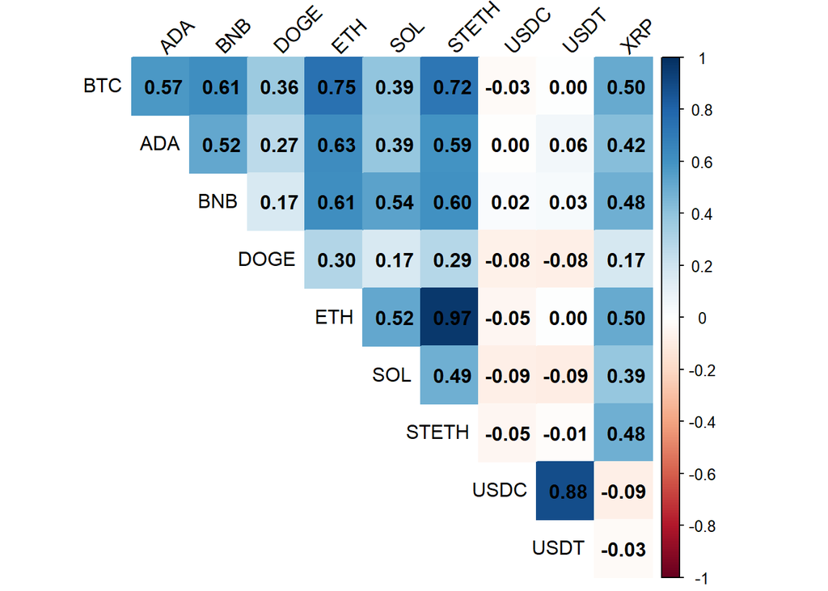

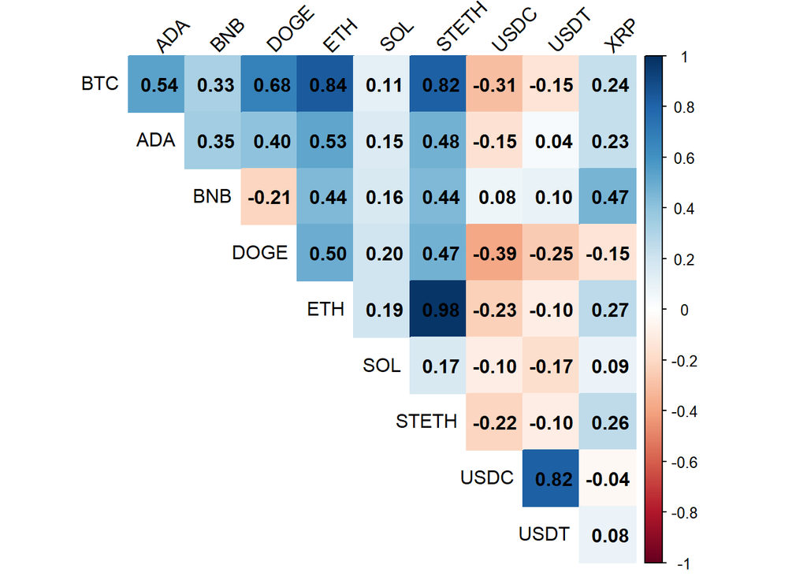

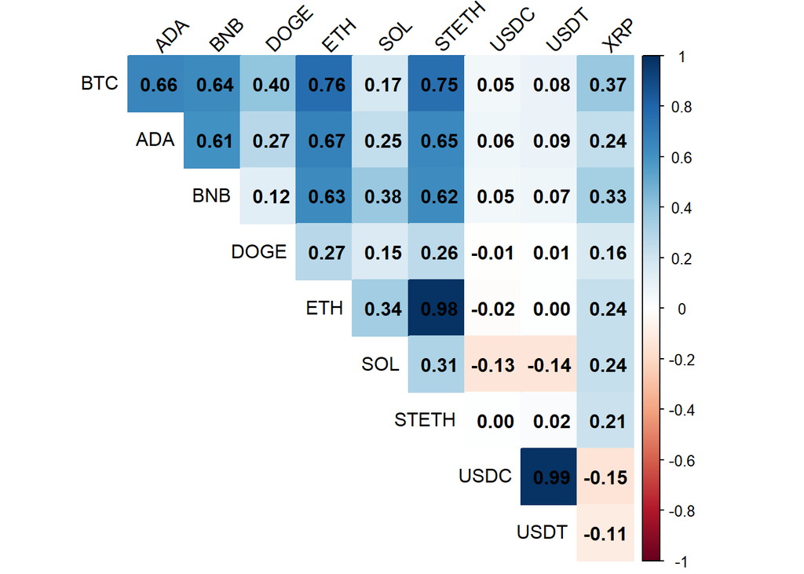

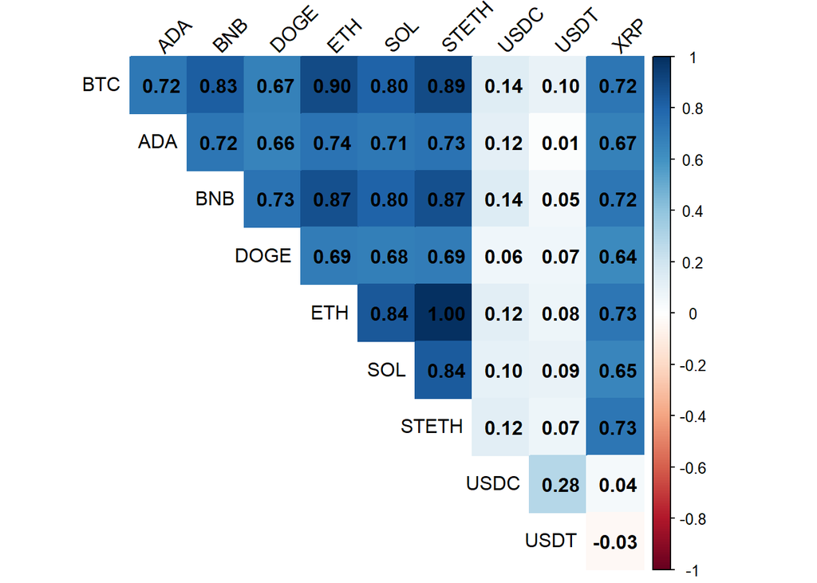

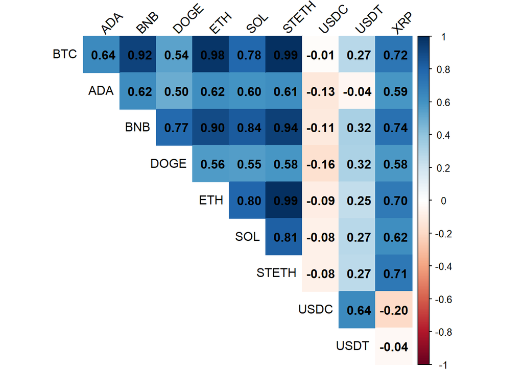

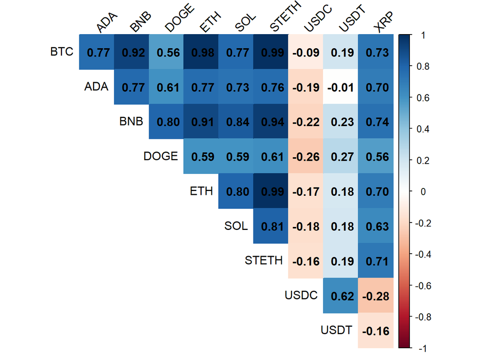

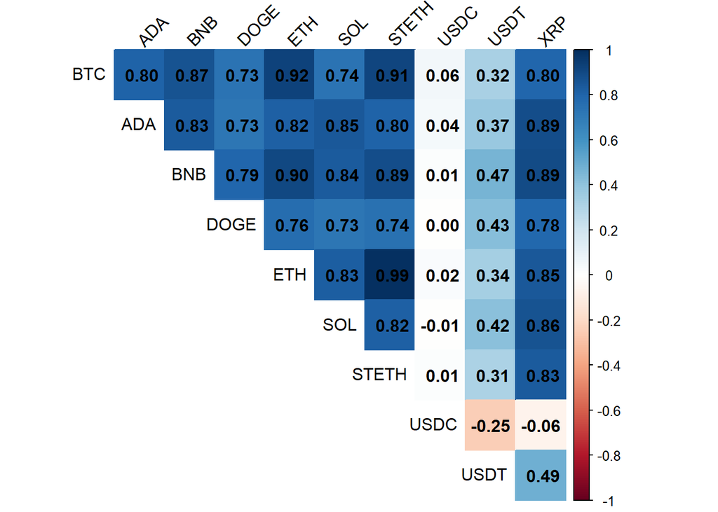

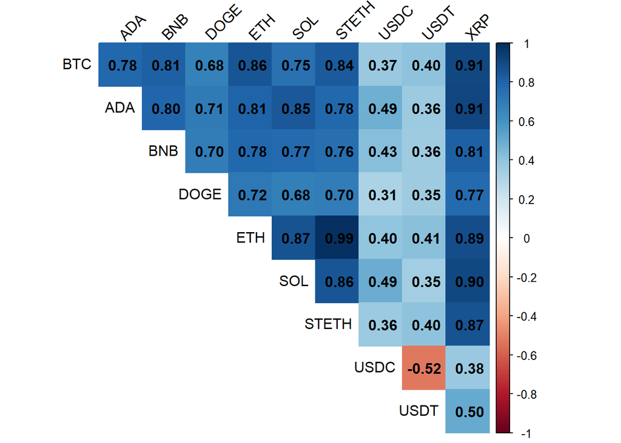

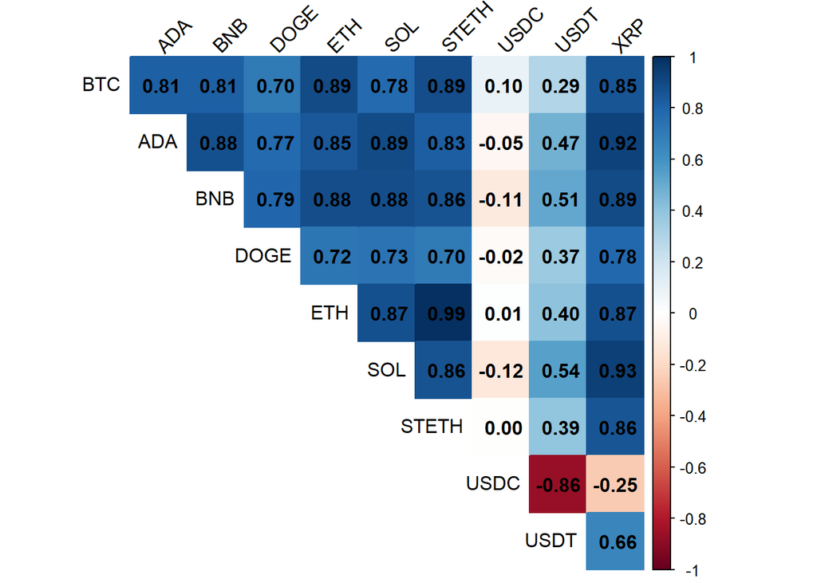

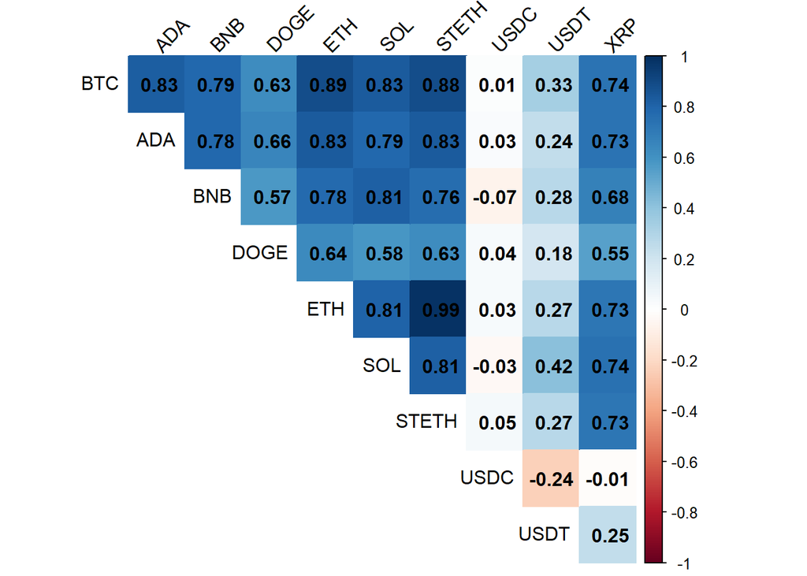

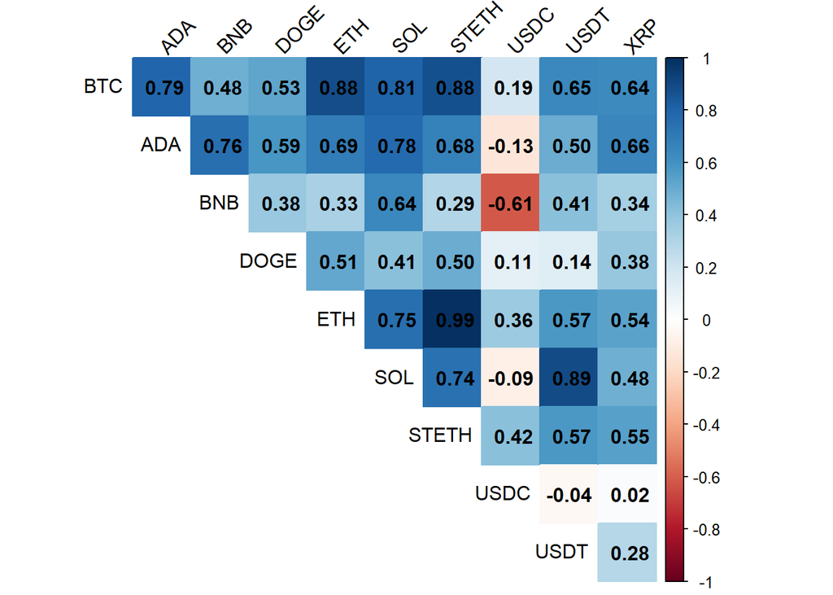

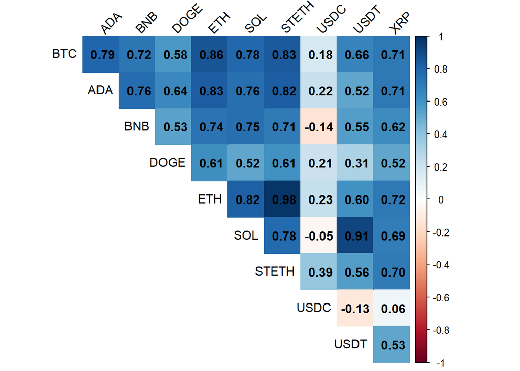

```r
for (period in names(df_list)) {

  df <- df_list[[period]]
  sim <- sim_list[[period]]

  # 1. Raw data
  cor_raw <- cor(df, use = "pairwise.complete.obs")

  corrplot_save(
    filename = paste0("corr_", period, "_raw"),
    cor_matrix = cor_raw
  )


  # 2. GO-GARCH
  cor_gogarch <- cor(sim$x_sim_gogarch,use = "pairwise.complete.obs")

  corrplot_save(
    filename = paste0("corr_", period, "_gogarch"),
    cor_matrix = cor_gogarch
  )


  # 3. Vine + GO-GARCH
  cor_vine <- cor(sim$x_sim, use = "pairwise.complete.obs")

  corrplot_save(
    filename = paste0("corr_", period, "_vine"),
    cor_matrix = cor_vine
  )
}
```

```r
cor1 = cor(df_prebust,use = "pairwise.complete.obs")
cor2 = cor(sim_list$prebust$x_sim_gogarch,use = "pairwise.complete.obs")
cor3 = cor(sim_list$prebust$x_sim,use = "pairwise.complete.obs")


sqrt(colSums((cor2-cor1)^2)/9)
```

```
##   Close_BTC   Close_ADA   Close_BNB  Close_DOGE   Close_ETH   Close_SOL
##  0.10771177  0.13039925  0.13486127  0.15277943  0.11413404  0.10549076
## Close_STETH  Close_USDC  Close_USDT   Close_XRP
##  0.11524517  0.23546173  0.21001346  0.08887848
```

```r
sqrt(colSums((cor3-cor1)^2)/9)
```

```
##   Close_BTC   Close_ADA   Close_BNB  Close_DOGE   Close_ETH   Close_SOL
##   0.1077247   0.1094637   0.1430164   0.1469084   0.1140938   0.1059532
## Close_STETH  Close_USDC  Close_USDT   Close_XRP
##   0.1142365   0.3062054   0.1638180   0.1184320
```